# Chinese PhDs in the United States, Europe, and United Kingdom (1905-1962)

Episode 1: Mapping the Dissertations

Cécile Armand, Christian Henriot

2025-05-19

Abstract

This document is part of a series of three scripts developed to support a comprehensive study of early Chinese PhDs from 1905 to 1962. The study is based on a dataset derived from three catalogs of Chinese doctoral dissertations compiled by the librarian and bibliographer Yuan Tongli 袁同禮 (1895–1965), which cover the United States (1905–1960), the United Kingdom (1916–1961), and Continental Europe (1905–1962).The first script examines the dissertations themselves, while the second and third analyze the authors’ backgrounds and their post-graduation trajectories.

```r
# load packages

library(readr)
library(tidyverse)
library(hrbrthemes)
library(viridis)
library(FactoMineR)
library(Factoshiny)
library(networkD3)
library(BTM)
library(histtext)
```

# Introduction

This document is part of a series of three scripts developed to support a comprehensive study of early Chinese PhDs from 1905 to 1962. It is based on the three catalogs of Chinese doctoral dissertations compiled by the librarian and bibliographer Yuan Tongli 袁同禮 (1895–1965), covering the United States (1905–1960), the United Kingdom (1916–1961), and Continental Europe (1905–1962). These scripts provide the complete data and code underlying our analysis and narrative—material that could not be included in the final published work—to ensure transparency and enable rigorous traceability of our methods for interested readers.

The documentation series follows the general structure of the paper and includes:

1. **Script 1 analyzes the dissertations themselves**, examining their temporal and geographical distribution, disciplinary majors, host institutions, and research topics. This analysis is based exclusively on the original dissertation catalog.
2. **Script 2 focuses on the authors—the Chinese PhDs** who produced these dissertations—exploring their backgrounds using additional external data compiled by the Lee-Campbell Research Group.
3. **Script 3 investigates the post-graduation trajectories** of these PhDs, particularly their experiences following the 1949 Communist Revolution. This analysis leverages biographical entries available in online sources such as Wikipedia and Baidu.

As illustrated by the figure and table below, we lost a significant number of individuals when incorporating external sources, resulting in a reduced sample size compared to our initial population. Nonetheless, the integration of qualitative biographical information enables us to draw more nuanced and in-depth insights into the life experiences of a substantial subset of PhDs. This approach ultimately supports robust empirical conclusions grounded in rich, contextual data.

|  | Matched in CUSD-OS | (%) | Found in Baidu/Wikipedia | (%) |
| --- | --- | --- | --- | --- |
| USA | 2,315 | 83.4% | 681 | 24.5% |
| Europe | 1,113 | 71.3% | 268 | 17.2% |
| UK | 288 | 83.2% | 130 | 37.6% |
| Total | 3,716 | 79.4% | 1,079 | 23.0% |

[figure not shown]

The Early Chinese PhD Population Through Concentric Circles of Documentation

# Dataset

The dataset **phd_all_master** is a compilation of the three lists of doctors from the U.S., U.K. and Europe:

```r
library(readr)
phd_all_master <- read_delim("Data/phd_all_master.csv",
    delim = ";", escape_double = FALSE, trim_ws = TRUE)
```

```r
phd_all_master
```

| ID | Srce_ID | NameWG | NameZH | NamePY | Sex | Birth_year_Src | Birth_year_corr | Death_year | Age_Grad | Country | University | School | Discipline_Srce | Degree | Degree_Year | Degree_Period2 | Degree_Period | Thesis | Title_Src | Discipline | Field | Region | City | State | RID | Lat | Long |
| --- | --- | --- | --- | --- | --- | --- | --- | --- | --- | --- | --- | --- | --- | --- | --- | --- | --- | --- | --- | --- | --- | --- | --- | --- | --- | --- | --- |
| 741 | 741 | Wang, Chung-Hui | 王寵惠 | Wang Chonghui | NA | 1882 | 1882 | NA | 23 | United States | Yale University | NA | Law | D.C.L. | 1905 | 1905-1918 | 1905-1926 | Domicil: a study in comparative law | Domicil: a study in comparative law | Law | Humanities and social sciences | USA | New Haven | Connecticut | US1711 | 41.31130 | -72.92460 |
| 842 | 842 | Yen, Ching-Yung | 嚴錦榮 | Yan Jinrong | NA | NA | NA | NA | NA | United States | Columbia University | NA | Law | Ph.D | 1905 | 1905-1918 | 1905-1926 | Rights of citizens and persons under the Fourteenth amendment | Rights of citizens and persons under the Fourteenth amendment | Law | Humanities and social sciences | USA | New York | New York | US1947 | 40.69430 | -73.92490 |
| 95 | 95 | Chen, Chin-Tao | 陳錦濤 | Chen Jintao | NA | 1871 | 1871 | NA | 35 | United States | Yale University | NA | Economics And Business Administration | Ph.D | 1906 | 1905-1918 | 1905-1926 | Societary circulation | Societary circulation | Economics | Humanities and social sciences | USA | New Haven | Connecticut | US1688 | 41.31130 | -72.92460 |
| 542 | 747 | Ma, Do-Yun | 馬徳潤 | Ma Derun | NA | NA | NA | NA | NA | Germany | Berlin | NA | Law and Political Science | Ph.D. | 1907 | 1905-1918 | 1905-1926 | The entry of the Chinese Empire into the international legal community | Der Eintritt des chinesischen Reiches in den völkerrechtlichen Verband | International Law and Relations | Humanities and social sciences | Europe | Berlin | NA | EU714 | 52.52000 | 13.40500 |
| 351 | 886 | Li, Fo Ki | 李賦基 | Li Fuji | NA | NA | NA | NA | NA | Germany | Berlin | NA | Maths and Natural Science | Ph.D. | 1907 | 1905-1918 | 1905-1926 | Spectroscopic Investigations into P. Lenard's Theory of the Spectra of Alkali Metals... | Spektroskopische Untersuchungen über P. Lenards Theorie der Spektren der Alkali-metalle ... | Physics | Physical and earth sciences | Europe | Berlin | NA | EU687 | 52.52000 | 13.40500 |
| 1226 | 815 | Tsur, Nyok-Ching | 周毅卿 | Zhou Yiqing | NA | NA | NA | NA | NA | Germany | Leipzig | NA | Philosophy | Ph.D. | 1909 | 1905-1918 | 1905-1926 | Commercial Forms of the City of Ningbo | Die gewerblichen Betriebsformen der Stadt Ningpo | Economics | Humanities and social sciences | Europe | Leipzig | NA | EU1212 | 51.33970 | 12.37310 |
| 2675 | 2675 | Yen, Fu-Chun | 顔福慶 | Yan Fuqing | NA | 1882 | 1882 | NA | 27 | United States | Yale University | NA | Medicine And Surgery | MD | 1909 | 1905-1918 | 1905-1926 | A study of the cutaneous method of Von Pirquet and the per cutaneous method of Moco and their ccmparison with other tuberculin tests in the diagnosis of tuberculosis | A study of the cutaneous method of Von Pirquet and the per cutaneous method of Moco and their ccmparison with other tuberculin tests in the diagnosis of tuberculosis | Hygiene, Medicine and Pharmacy | Health sciences | USA | New Haven | Connecticut | US1743 | 41.31130 | -72.92460 |
| 1228 | 751 | Tschou, Tso-Tschun | 周澤春 | Zhou Zechun | NA | NA | NA | NA | NA | Germany | Berlin | NA | Philosophy | Ph.D. | 1909 | 1905-1918 | 1905-1926 | The Reforms of the Chinese Empire in Constitution, Administration, and Jurisprudence with Regards to Corresponding Institutions in Europe | Die Reformen des chinesischen Reiches in Verfassung, Verwaltung und Rechtsprechung mit Rücksicht auf die entsprechenden Einrichtungen Europas | Political Science | Humanities and social sciences | Europe | Berlin | NA | EU826 | 52.52000 | 13.40500 |
| 130 | 130 | Chen, Wei-Cheng | 陳維城 | Chen Weicheng | NA | 1882 | 1882 | NA | 28 | United States | University of Michigan | NA | Religion | Ph.D | 1910 | 1905-1918 | 1905-1926 | The educational work of missionaries in China | The educational work of missionaries in China | Philosophy and Theology | Humanities and social sciences | USA | Ann Arbor | Michigan | US79 | 42.27590 | -83.73100 |
| 1405 | 1405 | Fung, Hing-Kwai | 馮慶桂 | Feng Qinggui | NA | 1882 | 1882 | NA | 29 | United States | Cornell University | NA | Botany And Plant Culture | Ph.D | 1911 | 1905-1918 | 1905-1926 | An ecological study of the American cotton plant with incidental reference to its possible adaptability in China | An ecological study of the American cotton plant with incidental reference to its possible adaptability in China | Botany | Biological sciences | USA | Ithaca | New York | US1267 | 42.44420 | -76.50320 |

[output cut: 4707 more lines]

```r
names(phd_all_master)
```

```
##  [1] "ID"              "Srce_ID"         "NameWG"          "NameZH"
##  [5] "NamePY"          "Sex"             "Birth_year_Src"  "Birth_year_corr"
##  [9] "Death_year"      "Age_Grad"        "Country"         "University"
## [13] "School"          "Discipline_Srce" "Degree"          "Degree_Year"
## [17] "Degree_Period2"  "Degree_Period"   "Thesis"          "Title_Src"
## [21] "Discipline"      "Field"           "Region"          "City"
## [25] "State"           "RID"             "Lat"             "Long"
```

The dataset contains 4,717 unique dissertations (rows) and 28 attributes on these dissertations and their authors, including

- the various identifiers: unique individual (doctor) (ID), source ID (Srce_ID)
- biographical information on doctors: names, gender, year of birth, year of death
- information on dissertations: information: age at graduation, region and country of graduation, university of graduation, discipline of graduation, year of graduation, title of dissertation (as in source, and translated)
- spatial data: city of university, geographical coordinates

# Geographical Distribution

Geographical distribution of PhDs by world region and by country:

```r
phd_all_master %>% group_by(Region) %>% count(sort = TRUE)
```

| Region | n |
| --- | --- |
| USA | 2782 |
| Europe | 1583 |
| UK | 352 |

```r
phd_all_master %>% group_by(Country) %>% count(sort = TRUE)
```

| Country | n |
| --- | --- |
| United States | 2754 |
| Germany | 734 |
| France | 586 |
| United Kingdom | 352 |
| Italy | 103 |
| Switzerland | 54 |
| Netherlands | 52 |
| Belgium | 34 |
| Canada | 28 |
| Spain | 11 |

[output cut: 1 more lines]

# Timeline

When did they graduate?

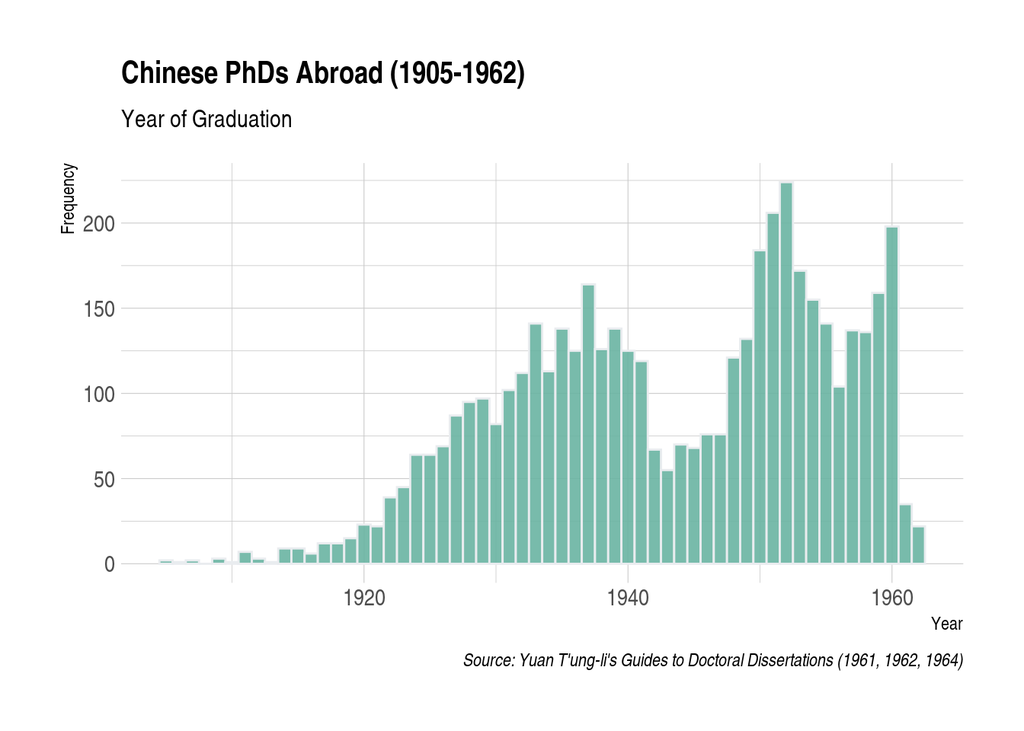

```r
phd_all_master %>% drop_na(Degree_Year) %>%
  ggplot( aes(x=Degree_Year)) +
  geom_histogram( binwidth=1, fill="#69b3a2", color="#e9ecef", alpha=0.9) +
  ggtitle("Bin size = 1") +
  theme_ipsum() +
  theme(
    plot.title = element_text(size=15)
  ) +
  labs(title = "Chinese PhDs Abroad (1905-1962)",
       subtitle = "Year of Graduation",
       x = "Year",
       y = "Frequency",
       caption = "Source: Yuan T'ung-li's Guides to Doctoral Dissertations (1961, 1962, 1964)")
```

## By Region

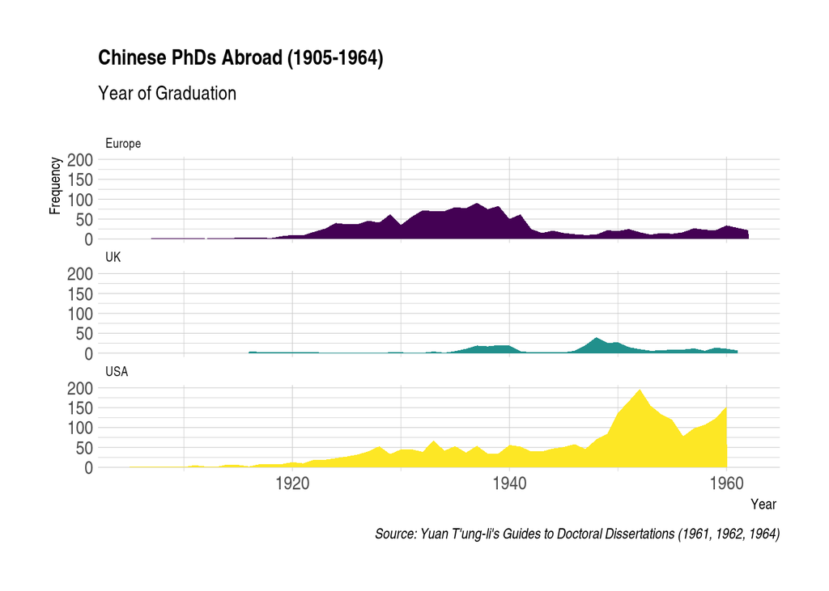

```r
phd_all_master %>%
  group_by(Region, Degree_Year) %>%
  count() %>%
  ggplot( aes(x=Degree_Year, y=n, group=Region, fill=Region)) +
  geom_area() +
  scale_fill_viridis(discrete = TRUE) +
  theme(legend.position="none") +
  labs(title = "Chinese PhDs Abroad (1905-1964)",
       subtitle = "Year of Graduation",
       x = "Year ",
       y = "Frequency",
       caption = "Source: Yuan T'ung-li's Guides to Doctoral Dissertations (1961, 1962, 1964)") +
  theme_ipsum() +
  theme(
    legend.position="none",
    panel.spacing = unit(0, "lines"),
    strip.text.x = element_text(size = 8),
    plot.title = element_text(size=13)
  ) +
  facet_wrap(~Region, ncol = 1)
```

## Periodization

```r
phd_all_master %>% group_by(Degree_Period) %>% count(sort = TRUE) # taking the Nationalist takeover as a cut-off
```

| Degree_Period | n |
| --- | --- |
| 1938-1951 | 1563 |
| 1952-1962 | 1483 |
| 1927-1937 | 1256 |
| 1905-1926 | 409 |
| NA | 6 |

```r
phd_all_master %>% group_by(Degree_Period2) %>% count(sort = TRUE) # taking end of WWI as a cut-off
```

| Degree_Period2 | n |
| --- | --- |
| 1938-1951 | 1563 |
| 1952-1962 | 1483 |
| 1927-1937 | 1256 |
| 1919-1926 | 341 |
| 1905-1918 | 68 |
| NA | 6 |

# Universities

From which university did they graduate?

Distribution by institution, as well as distribution of institutions by region, country, and period of graduation:

```r
phd_all_master %>% group_by(University) %>% count(sort = TRUE)
```

| University | n |
| --- | --- |
| Paris | 326 |
| Berlin | 205 |
| University of Illinois | 205 |
| Columbia University | 200 |
| Harvard University | 165 |
| University of Michigan | 148 |
| Cornell University | 144 |
| University of Chicago | 143 |
| University of Wisconsin–Madison | 134 |
| Lyon | 125 |

[output cut: 224 more lines]

```r
phd_all_master %>% group_by(Region, University) %>% count(sort = TRUE) # by region
```

| Region | University | n |
| --- | --- | --- |
| Europe | Paris | 326 |
| Europe | Berlin | 205 |
| USA | University of Illinois | 205 |
| USA | Columbia University | 200 |
| USA | Harvard University | 165 |
| USA | University of Michigan | 148 |
| USA | Cornell University | 144 |
| USA | University of Chicago | 143 |
| USA | University of Wisconsin–Madison | 134 |
| Europe | Lyon | 125 |

[output cut: 224 more lines]

```r
phd_all_master %>% group_by(Country, University) %>% count(sort = TRUE) # by country
```

| Country | University | n |
| --- | --- | --- |
| France | Paris | 326 |
| Germany | Berlin | 205 |
| United States | University of Illinois | 205 |
| United States | Columbia University | 200 |
| United States | Harvard University | 165 |
| United States | University of Michigan | 148 |
| United States | Cornell University | 144 |
| United States | University of Chicago | 143 |
| United States | University of Wisconsin–Madison | 134 |
| France | Lyon | 125 |

[output cut: 224 more lines]

```r
phd_all_master %>% group_by(Degree_Period, University) %>% count() %>% arrange(Degree_Period, desc(n)) # by period
```

| Degree_Period | University | n |
| --- | --- | --- |
| 1905-1926 | Columbia University | 53 |
| 1905-1926 | Berlin | 45 |
| 1905-1926 | Paris | 33 |
| 1905-1926 | Harvard University | 21 |
| 1905-1926 | University of Chicago | 20 |
| 1905-1926 | Cornell University | 17 |
| 1905-1926 | Lyon | 16 |
| 1905-1926 | Frankfurt | 11 |
| 1905-1926 | Edinburgh | 8 |
| 1905-1926 | Freiburg im Breisgau | 8 |

[output cut: 532 more lines]

# Cities (GIS)

```r
library(leaflet)

map_all <- phd_all_master %>% group_by(City, Lat, Long) %>%
  count() %>%
  leaflet() %>%
  addTiles() %>%
  addCircleMarkers( radius = ~log(n)*3,
                    label = ~City,
                    color = "white",
                    weight = 1,
                    opacity = 0.6,
                    fill = TRUE,
                    fillColor = "red",
                    fillOpacity = 0.9,
                    stroke = TRUE,
                    popup = ~paste( "City:", City ,
                                    "",
                                    "Chinese PhDs, 1905-1962", n))

# add legend

legend_html <- "
<div style='background-color: white; padding: 10px;'>
  <h4>Chinese PhDs, 1905-1962</h4>
  <div style='display: flex; align-items: center;'>
    <div style='background-color: red; width: 20px; height: 20px; border-radius: 50%; margin-right: 5px;'></div>
    <span>10</span>
  </div>
  <div style='display: flex; align-items: center;'>
    <div style='background-color: red; width: 25px; height: 25px; border-radius: 50%; margin-right: 5px;'></div>
    <span>20</span>
  </div>
  <div style='display: flex; align-items: center;'>
    <div style='background-color: red; width: 30px; height: 30px; border-radius: 50%; margin-right: 5px;'></div>
    <span>50</span>
  </div>
  <div style='display: flex; align-items: center;'>
    <div style='background-color: red; width: 35px; height: 35px; border-radius: 50%; margin-right: 5px;'></div>
    <span>100</span>
  </div>
</div>
"

# Add the custom legend to the map
map_all %>%
  addControl(html = legend_html, position = "bottomright")
```

[interactive chart not shown]

### 1905-1926

```r
map1 <- phd_all_master %>%
  filter(Degree_Period == "1905-1926") %>%
  group_by(City, Lat, Long) %>%
  count() %>%
  leaflet() %>%
  addTiles() %>%
  addCircleMarkers( radius = ~log(n)*3,
                    label = ~City,
                    color = "white",
                    weight = 1,
                    opacity = 0.6,
                    fill = TRUE,
                    fillColor = "orange",
                    fillOpacity = 0.9,
                    stroke = TRUE,
                    popup = ~paste( "City:", City ,
                                    "<br>",
                                    "Chinese PhDs, 1905-1926:", n))


legend1 <- "
<div style='background-color: white; padding: 10px;'>
  <h4>Chinese PhDs, 1905-1926</h4>
  <div style='display: flex; align-items: center;'>
    <div style='background-color: orange; width: 20px; height: 20px; border-radius: 50%; margin-right: 5px;'></div>
    <span>10</span>
  </div>
  <div style='display: flex; align-items: center;'>
    <div style='background-color: orange; width: 25px; height: 25px; border-radius: 50%; margin-right: 5px;'></div>
    <span>20</span>
  </div>
  <div style='display: flex; align-items: center;'>
    <div style='background-color: orange; width: 30px; height: 30px; border-radius: 50%; margin-right: 5px;'></div>
    <span>50</span>
  </div>
  <div style='display: flex; align-items: center;'>
    <div style='background-color: orange; width: 35px; height: 35px; border-radius: 50%; margin-right: 5px;'></div>
    <span>100</span>
  </div>
</div>
"

# Add the custom legend to the map
map1 %>%
  addControl(html = legend1, position = "bottomright")
```

[interactive chart not shown]

### 1927-1937

```r
map2 <- phd_all_master %>%
  filter(Degree_Period == "1927-1937") %>%
  group_by(City, Lat, Long) %>%
  count() %>%
  leaflet() %>%
  addTiles() %>%
  addCircleMarkers( radius = ~log(n)*3,
                    label = ~City,
                    color = "white",
                    weight = 1,
                    opacity = 0.6,
                    fill = TRUE,
                    fillColor = "blue",
                    fillOpacity = 0.9,
                    stroke = TRUE,
                    popup = ~paste( "City:", City ,
                                    "",
                                    "Chinese PhDs, 1927-1937", n))


legend2 <- "
<div style='background-color: white; padding: 10px;'>
  <h4>Chinese PhDs, 1927-1937</h4>
  <div style='display: flex; align-items: center;'>
    <div style='background-color: blue; width: 20px; height: 20px; border-radius: 50%; margin-right: 5px;'></div>
    <span>10</span>
  </div>
  <div style='display: flex; align-items: center;'>
    <div style='background-color: blue; width: 25px; height: 25px; border-radius: 50%; margin-right: 5px;'></div>
    <span>20</span>
  </div>
  <div style='display: flex; align-items: center;'>
    <div style='background-color: blue; width: 30px; height: 30px; border-radius: 50%; margin-right: 5px;'></div>
    <span>50</span>
  </div>
  <div style='display: flex; align-items: center;'>
    <div style='background-color: blue; width: 35px; height: 35px; border-radius: 50%; margin-right: 5px;'></div>
    <span>100</span>
  </div>
</div>
"

# Add the custom legend to the map
map2 %>%
  addControl(html = legend2, position = "bottomright")
```

[interactive chart not shown]

### 1938-1951

```r
map3 <- phd_all_master %>%
  filter(Degree_Period == "1938-1951") %>%
  group_by(City, Lat, Long) %>%
  count() %>%
  leaflet() %>%
  addTiles() %>%
  addCircleMarkers( radius = ~log(n)*3,
                    label = ~City,
                    color = "white",
                    weight = 1,
                    opacity = 0.6,
                    fill = TRUE,
                    fillColor = "darkgreen",
                    fillOpacity = 0.9,
                    stroke = TRUE,
                    popup = ~paste( "City:", City ,
                                    "",
                                    "Chinese PhDs, 1938-1951", n))


legend3 <- "
<div style='background-color: white; padding: 10px;'>
  <h4>Chinese PhDs, 1938-1951</h4>
  <div style='display: flex; align-items: center;'>
    <div style='background-color: darkgreen; width: 20px; height: 20px; border-radius: 50%; margin-right: 5px;'></div>
    <span>10</span>
  </div>
  <div style='display: flex; align-items: center;'>
    <div style='background-color: darkgreen; width: 25px; height: 25px; border-radius: 50%; margin-right: 5px;'></div>
    <span>20</span>
  </div>
  <div style='display: flex; align-items: center;'>
    <div style='background-color: darkgreen; width: 30px; height: 30px; border-radius: 50%; margin-right: 5px;'></div>
    <span>50</span>
  </div>
  <div style='display: flex; align-items: center;'>
    <div style='background-color: darkgreen; width: 35px; height: 35px; border-radius: 50%; margin-right: 5px;'></div>
    <span>100</span>
  </div>
</div>
"

# Add the custom legend to the map
map3 %>%
  addControl(html = legend3, position = "bottomright")
```

[interactive chart not shown]

### 1952-1962

```r
map4 <- phd_all_master %>%
  filter(Degree_Period == "1952-1962") %>%
  group_by(City, Lat, Long) %>%
  count() %>%
  leaflet() %>%
  addTiles() %>%
  addCircleMarkers( radius = ~log(n)*3,
                    label = ~City,
                    color = "white",
                    weight = 1,
                    opacity = 0.6,
                    fill = TRUE,
                    fillColor = "purple",
                    fillOpacity = 0.9,
                    stroke = TRUE,
                    popup = ~paste( "City:", City ,
                                    "",
                                    "Chinese PhDs, 1952-1962", n))


legend4 <- "
<div style='background-color: white; padding: 10px;'>
  <h4>Chinese PhDs, 1952-1962</h4>
  <div style='display: flex; align-items: center;'>
    <div style='background-color: purple; width: 20px; height: 20px; border-radius: 50%; margin-right: 5px;'></div>
    <span>10</span>
  </div>
  <div style='display: flex; align-items: center;'>
    <div style='background-color: purple; width: 25px; height: 25px; border-radius: 50%; margin-right: 5px;'></div>
    <span>20</span>
  </div>
  <div style='display: flex; align-items: center;'>
    <div style='background-color: purple; width: 30px; height: 30px; border-radius: 50%; margin-right: 5px;'></div>
    <span>50</span>
  </div>
  <div style='display: flex; align-items: center;'>
    <div style='background-color: purple; width: 35px; height: 35px; border-radius: 50%; margin-right: 5px;'></div>
    <span>100</span>
  </div>
</div>
"

# Add the custom legend to the map
map4 %>%
  addControl(html = legend4, position = "bottomright")
```

[interactive chart not shown]

# Disciplines

```r
# all regions included
phd_all_master %>% group_by(Field) %>% count(sort = TRUE)
```

| Field | n |
| --- | --- |
| Humanities and social sciences | 1620 |
| Physical and earth sciences | 1130 |
| Biological sciences | 727 |
| Engineering sciences | 717 |
| Health sciences | 491 |
| Other | 17 |
| NA | 15 |

```r
phd_all_master %>% group_by(Discipline) %>% count(sort = TRUE)
```

| Discipline | n |
| --- | --- |
| Chemistry | 597 |
| Economics | 409 |
| Hygiene, Medicine and Pharmacy | 403 |
| Biology | 274 |
| Physics | 272 |
| International Law and Relations | 188 |
| Education | 180 |
| Botany | 174 |
| Law | 163 |
| Philosophy and Theology | 150 |

[output cut: 31 more lines]

```r
# by regions

phd_all_master %>% group_by(Region) %>% count(Field) %>% arrange(Region, desc(n))
```

| Region | Field | n |
| --- | --- | --- |
| Europe | Humanities and social sciences | 659 |
| Europe | Health sciences | 329 |
| Europe | Physical and earth sciences | 273 |
| Europe | Biological sciences | 218 |
| Europe | Engineering sciences | 75 |
| Europe | Other | 17 |
| Europe | NA | 12 |
| UK | Physical and earth sciences | 121 |
| UK | Humanities and social sciences | 88 |
| UK | Biological sciences | 70 |

[output cut: 8 more lines]

```r
phd_all_master %>% group_by(Region) %>% count(Discipline) %>% arrange(Region, desc(n))
```

| Region | Discipline | n |
| --- | --- | --- |
| Europe | Hygiene, Medicine and Pharmacy | 321 |
| Europe | Biology | 186 |
| Europe | Chemistry | 148 |
| Europe | Economics | 146 |
| Europe | Law | 116 |
| Europe | International Law and Relations | 80 |
| Europe | Philosophy and Theology | 74 |
| Europe | Engineering | 65 |
| Europe | Political Science | 54 |
| Europe | Physics | 50 |

[output cut: 91 more lines]

```r
# by periods

phd_all_master %>% group_by(Degree_Period) %>% count(Field) %>% arrange(Degree_Period, desc(n))
```

| Degree_Period | Field | n |
| --- | --- | --- |
| 1905-1926 | Humanities and social sciences | 193 |
| 1905-1926 | Health sciences | 90 |
| 1905-1926 | Physical and earth sciences | 57 |
| 1905-1926 | Biological sciences | 46 |
| 1905-1926 | Engineering sciences | 23 |
| 1927-1937 | Humanities and social sciences | 575 |
| 1927-1937 | Physical and earth sciences | 236 |
| 1927-1937 | Biological sciences | 192 |
| 1927-1937 | Health sciences | 171 |
| 1927-1937 | Engineering sciences | 71 |

[output cut: 18 more lines]

```r
phd_all_master %>% group_by(Degree_Period) %>% count(Discipline) %>% arrange(Degree_Period, desc(n))
```

| Degree_Period | Discipline | n |
| --- | --- | --- |
| 1905-1926 | Hygiene, Medicine and Pharmacy | 80 |
| 1905-1926 | Economics | 54 |
| 1905-1926 | Chemistry | 34 |
| 1905-1926 | Biology | 29 |
| 1905-1926 | International Law and Relations | 28 |
| 1905-1926 | Political Science | 23 |
| 1905-1926 | Education | 21 |
| 1905-1926 | Philosophy and Theology | 17 |
| 1905-1926 | Physics | 15 |
| 1905-1926 | Law | 14 |

[output cut: 139 more lines]

# Correspondence Analyses

## Region and Field (CA)

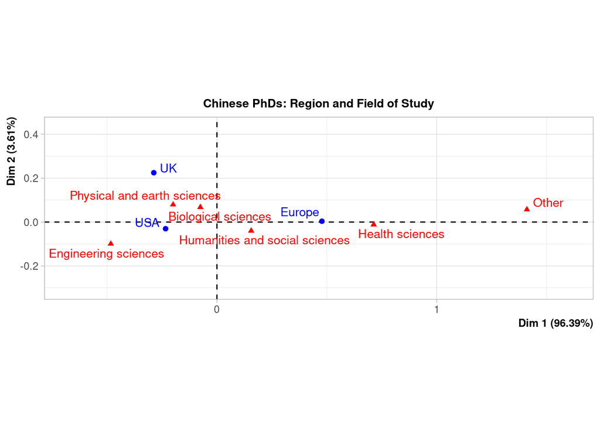

```r
region_field <- phd_all_master %>%
  drop_na(Field) %>%
  select(Field, Region) %>%
  group_by(Region, Field) %>%
  tally() %>%
  spread(key = Field, value = n)

# read first column as row names

region_field <- column_to_rownames(region_field, var = "Region")

# replace NA values with 0

region_field <- mutate_all(region_field, ~replace(., is.na(.), 0))

# load packages for CA

library(FactoMineR)

res.ca1<-CA(region_field,graph=FALSE)
plot.CA(res.ca1,cex=0.9,cex.main=0.9,cex.axis=0.9,title="Chinese PhDs: Region and Field of Study")
```

## Country and Discipline (CA)

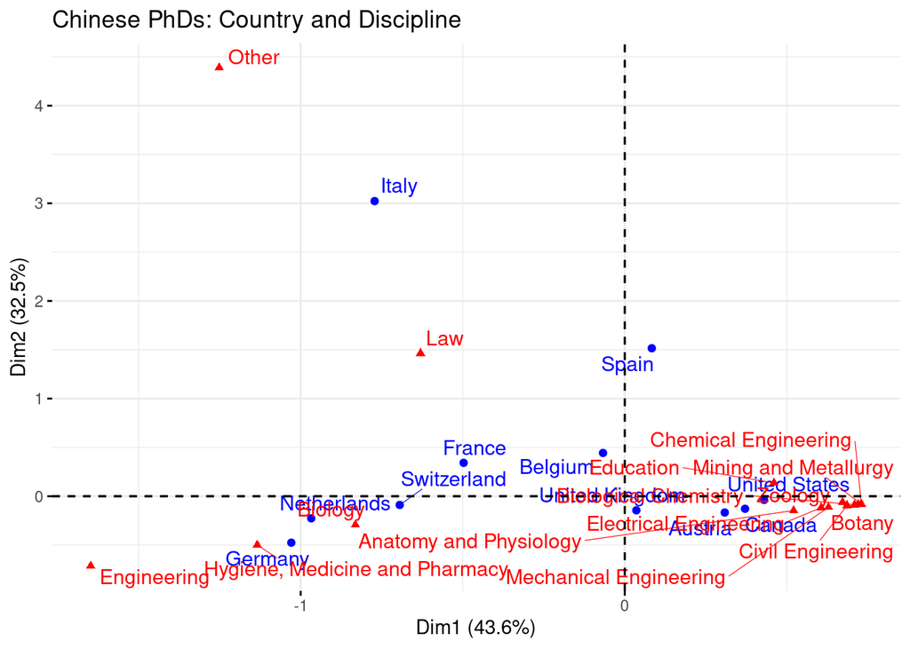

```r
country_disc <- phd_all_master %>%
  drop_na(Discipline) %>%
  select(Discipline, Country) %>%
  group_by(Country, Discipline) %>%
  tally() %>%
  spread(key = Discipline, value = n)

# read first column as row names

country_disc <- column_to_rownames(country_disc, var = "Country")

# replace NA values with 0

country_disc <- mutate_all(country_disc, ~replace(., is.na(.), 0))

# load packages for CA

library(factoextra)

res.ca2<-CA(country_disc,graph=FALSE)

# Get the contributions of the columns (disciplines)
col_contrib <- get_ca_col(res.ca2)$contrib


# For example, highlight the top 5 contributing disciplines
top_disciplines <- names(sort(col_contrib[,1], decreasing = TRUE))[1:15]

fviz_ca_biplot(res.ca2,
               repel = TRUE,
               title = "Chinese PhDs: Country and Discipline",
               cex = 0.5,
               cex.main = 0.8,
               cex.axis = 1,
               col.row = "blue",               # Set country labels and dots to blue
               col.col = "red",              # Set discipline labels and dots to red
               pointsize.col = col_contrib[,1]/max(col_contrib[,1]) * 5,  # Scale discipline dot sizes
               label = "all",                  # Show labels for both rows and columns
               select.col = list(name = top_disciplines))  # Limit discipline labels to top contributors)
```

## Region, Period, Field (MCA)

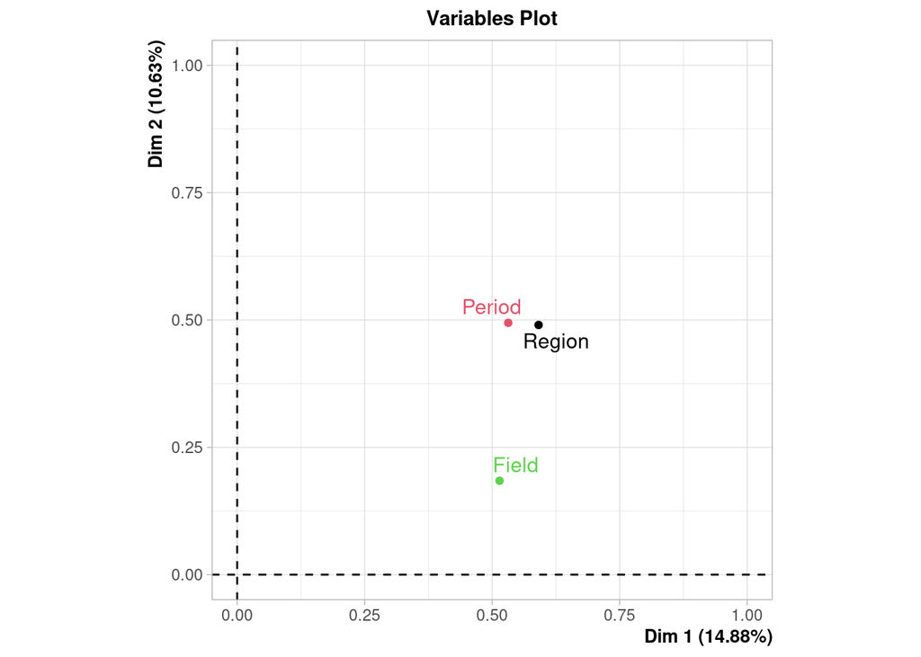

```r
mca_field_period <- phd_all_master %>% distinct(RID, Region, Degree_Period2, Field) %>% drop_na(RID, Region, Degree_Period2, Field) %>% rename(Period = Degree_Period2)
mca_field_period <- column_to_rownames(mca_field_period, "RID")

res.MCA<-MCA(mca_field_period,graph=FALSE)
plot.MCA(res.MCA, choix='var',title="Variables Plot",col.var=c(1,2,3))
```

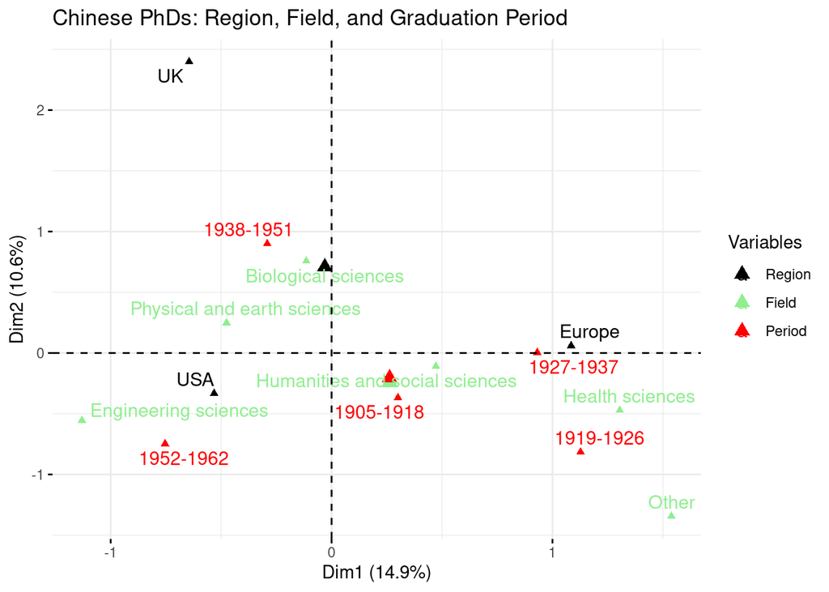

```r
# Create the MCA plot
mca_plot <- fviz_mca_var(res.MCA,
                         col.var = c("black", "black", "black", "red", "red", "red", "red", "red",
                                     "lightgreen", "lightgreen", "lightgreen", "lightgreen", "lightgreen", "lightgreen"),  # Updated colors
                         repel = TRUE,   # Avoid overlapping labels
                         title = "Chinese PhDs: Region, Field, and Graduation Period",  # Title
                         label = "var")  # Show only variable labels

# Customize the legend using ggplot2
mca_plot +
  scale_color_manual(
    values = c("black" = "black", "lightgreen" = "lightgreen", "red" = "red"),  # Map colors
    labels = c("Region", "Field", "Period")  # Custom legend labels
  ) +
  guides(color = guide_legend(title = "Variables"))
```

```r
library(explor)

explor(res.MCA)

res <- explor::prepare_results(res.MCA)
explor::MCA_var_plot(res, xax = 1, yax = 2, var_sup = FALSE, var_sup_choice = ,
                     var_lab_min_contrib = 0, col_var = "Variable", symbol_var = NULL, size_var = "Cos2",
                     size_range = c(52.5, 700), labels_size = 10, point_size = 56, transitions = TRUE,
                     labels_positions = NULL, labels_prepend_var = FALSE, xlim = c(-2.7, 2.53),
                     ylim = c(-2.04, 3.19))
```

## Region, Period, Discipline

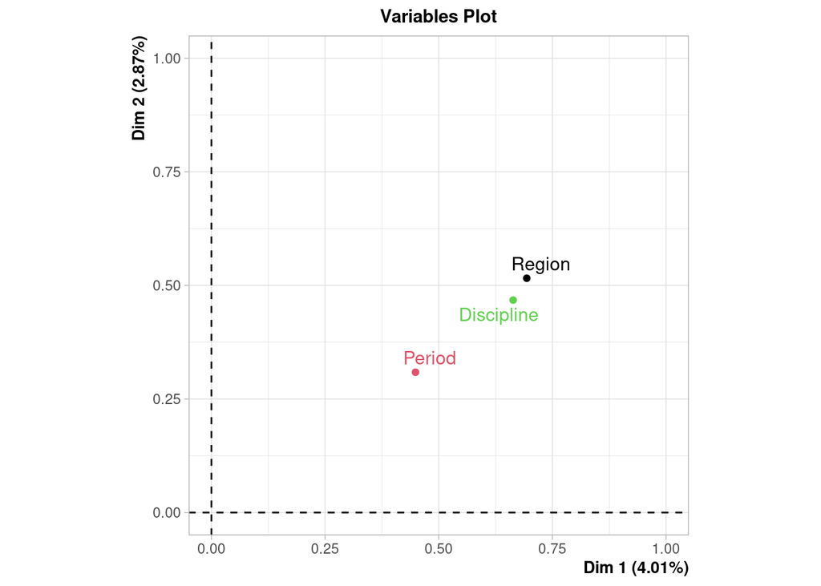

```r
mca_disc_period <- phd_all_master %>% distinct(RID, Region, Degree_Period2, Discipline) %>% drop_na(RID, Region, Degree_Period2, Discipline) %>% rename(Period = Degree_Period2)
mca_disc_period <- column_to_rownames(mca_disc_period, "RID")

res.MCA2<-MCA(mca_disc_period,graph=FALSE)
plot.MCA(res.MCA2, choix='var',title="Variables Plot",col.var=c(1,2,3))
```

```r
res <- explor::prepare_results(res.MCA2)
```

# Research Topics

```r
# filter theses in the Humanities and Social Sciences (1620)

phd_shs <- phd_all_master %>% filter(Field == "Humanities and social sciences") %>% drop_na(Thesis)
```

## Term Frequencies

```r
library(tidyverse)
library(tidytext)

# clean titles

phd_shs <- phd_shs %>%
  mutate(title = str_replace_all(Thesis, "[:digit:]", "")) %>%
  mutate(title = str_remove(title, "^The")) %>%
  mutate(title = str_remove(title, "^A")) %>%
  mutate(title = str_replace_all(title, "- ", " ")) %>%
  mutate(title = str_replace_all(title, "'s", "")) %>%
  mutate(title = str_replace_all(title, "\\, ", " ")) %>%
  mutate(title = str_replace_all(title, "China -", "China ")) %>%
  mutate(title = str_remove(title, "-$")) %>% # remove comma end of string
  mutate(title = str_remove(title, "\\.$")) %>%
  mutate(title = trimws(title, "both")) %>%
  mutate(title = str_squish(title)) %>%
  relocate(title, .after= Thesis) %>% mutate(published = str_extract(title, "Published"))%>%
  relocate(published, .after= title)

# tokenization (unigram)

library(tidytext)

data("stop_words")

shs_unigram <- phd_shs %>%
  unnest_tokens(output = word, input = title) %>%
  anti_join(stop_words)  # remove stop words

shs_unigram <- shs_unigram %>% mutate(lgth = nchar(word))

shs_unigram_count <- shs_unigram %>%
  group_by(word) %>%
  tally() %>%
  arrange(desc(n))

shs_unigram_count
```

| word | n |
| --- | --- |
| china | 467 |
| chinese | 306 |
| study | 246 |
| law | 104 |
| international | 83 |
| education | 82 |
| united | 78 |
| development | 73 |
| economic | 73 |
| foreign | 58 |

[output cut: 2693 more lines]

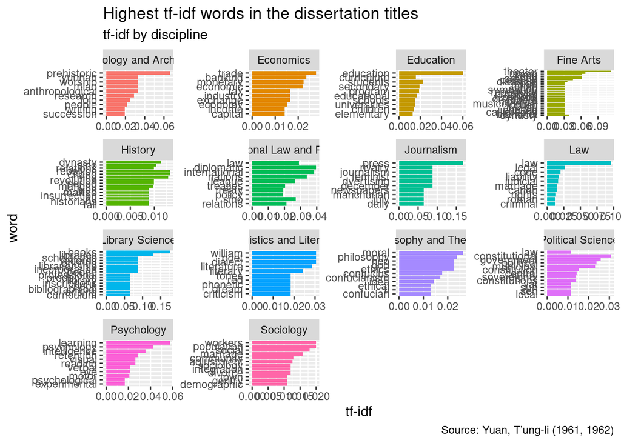

```r
# tf_idf by disciplines

shs_tf_idf_discipline <- shs_unigram %>%
  count(Discipline, word)  %>%
  bind_tf_idf(word, Discipline, n) %>%
  arrange(desc(tf_idf))

shs_tf_idf_discipline %>%
  group_by(Discipline) %>%
  top_n(10, tf_idf) %>%
  ungroup() %>%
  mutate(word = reorder(word, tf_idf)) %>%
  ggplot(aes(tf_idf, word, fill = Discipline)) +
  geom_col(show.legend = FALSE) +
  facet_wrap(~ Discipline, scales = "free") +
  labs(x = "tf-idf", y = "word",
       title = "Highest tf-idf words in the dissertation titles",
       subtitle = "tf-idf by discipline",
       caption = "Source: Yuan, T’ung-li (1961, 1962)")
```

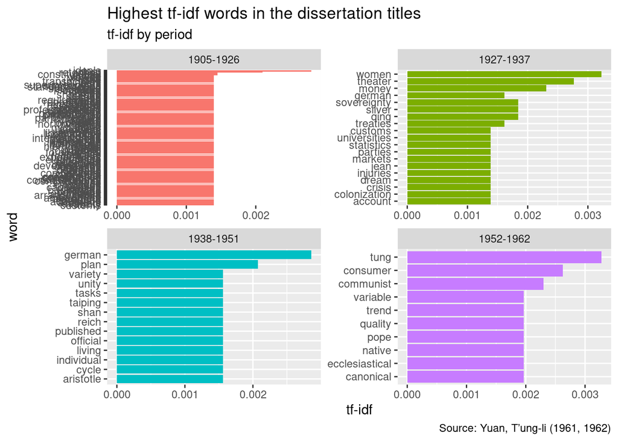

```r
# tf-idf by period

shs_tf_idf_period <- shs_unigram %>% filter(lgth >3) %>%
  filter(!word == "preface") %>%
  count(Degree_Period, word)  %>%
  bind_tf_idf(word, Degree_Period, n) %>%
  arrange(desc(tf_idf))

shs_tf_idf_period %>%
  group_by(Degree_Period) %>%
  top_n(10, tf_idf) %>%
  ungroup() %>%
  mutate(word = reorder(word, tf_idf)) %>%
  ggplot(aes(tf_idf, word, fill = Degree_Period)) +
  geom_col(show.legend = FALSE) +
  facet_wrap(~ Degree_Period, scales = "free") +
  labs(x = "tf-idf", y = "word",
       title = "Highest tf-idf words in the dissertation titles",
       subtitle = "tf-idf by period",
       caption = "Source: Yuan, T’ung-li (1961, 1962)")
```

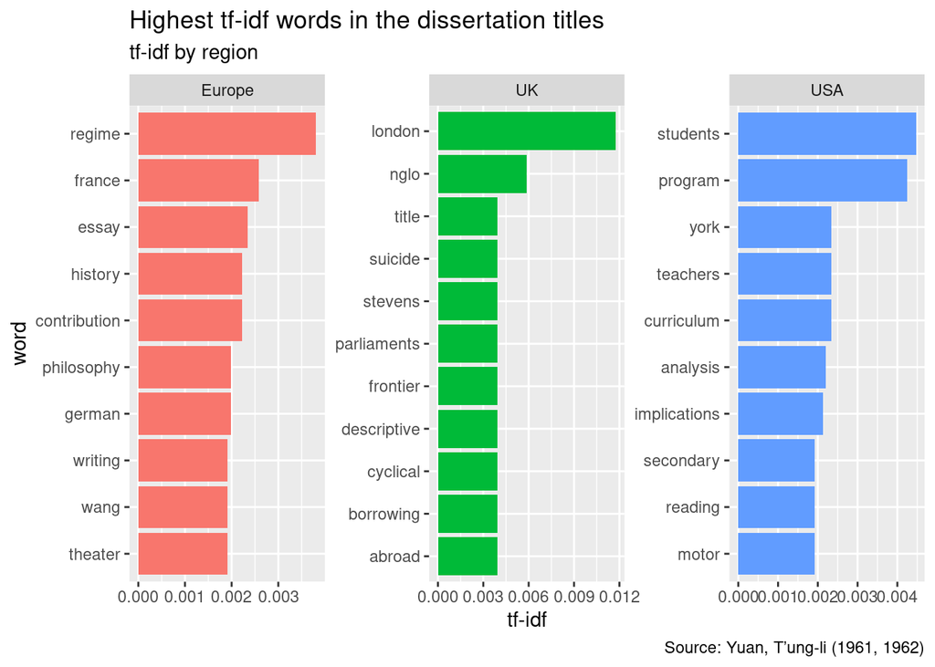

```r
# tf-idf by Region

shs_tf_idf_region <- shs_unigram %>%
  count(Region, word)  %>%
  bind_tf_idf(word, Region, n) %>%
  arrange(desc(tf_idf))

shs_tf_idf_region %>%
  group_by(Region) %>%
  top_n(10, tf_idf) %>%
  ungroup() %>%
  mutate(word = reorder(word, tf_idf)) %>%
  ggplot(aes(tf_idf, word, fill = Region)) +
  geom_col(show.legend = FALSE) +
  facet_wrap(~ Region, scales = "free") +
  labs(x = "tf-idf", y = "word",
       title = "Highest tf-idf words in the dissertation titles",
       subtitle = "tf-idf by region",
       caption = "Source: Yuan, T’ung-li (1961, 1962)")
```

## Semantic Networks

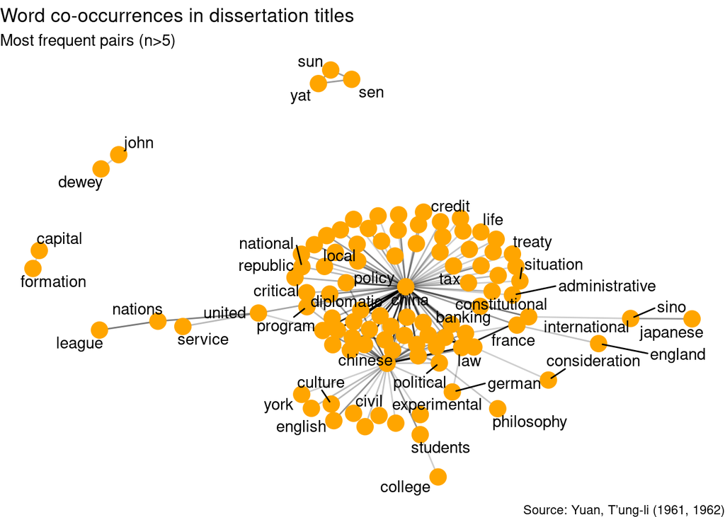

```r
library(widyr)

word_pairs <- shs_unigram %>%
  pairwise_count(word, RID, sort = TRUE)

word_pairs_filtered <- word_pairs %>% filter(!item1 == "study") %>% filter(!item2 == "study")

set.seed(2024)

library(igraph)
library(tidygraph)
library(ggraph)

word_pairs_filtered %>%
  filter(n > 5) %>%
  graph_from_data_frame() %>%
  ggraph(layout = "fr") +
  geom_edge_link(aes(edge_alpha = n), show.legend = FALSE) +
  geom_node_point(color = "orange", size = 5) +
  geom_node_text(aes(label = name), repel = TRUE, point.padding  = unit(0.2, "lines")) +
  theme_void()+
  labs(title = "Word co-occurrences in dissertation titles",
       subtitle = "Most frequent pairs (n>5)",
       caption = "Source: Yuan, T’ung-li (1961, 1962)")
```

```r
# Create a two-mode network linking titles and the words they contain

edge_2m <- shs_unigram %>% select(Thesis, word)
node_title <- edge_2m %>% distinct(Thesis) %>% rename(Name = Thesis) %>% mutate(Type = "Title")
node_word <- edge_2m %>% distinct(word) %>% rename(Name = word) %>% mutate(Type = "Word")
node <- bind_rows(node_title, node_word)


library(igraph)
title_net <- graph_from_data_frame(edge_2m, directed = FALSE, vertices = node)


# Community detection with Louvain

set.seed(2025)
title_net_cluster <- cluster_louvain(title_net)

# Extract community membership

title_net_cluster_df <- data.frame(title_net_cluster$membership,
                                   title_net_cluster$names) %>%
  group_by(title_net_cluster.membership) %>%
  add_tally() %>% # add size of clusters
  rename(member = title_net_cluster.names, cluster = title_net_cluster.membership, size = n)

## add node type and degree centrality

node_type <- node %>% rename(member = Name)
title_net_cluster_df <- left_join(title_net_cluster_df, node_type)

degree <- degree(title_net, mode = "all", normalized = FALSE)
degree_df <- as.data.frame(degree)
degree_df <- rownames_to_column(degree_df, "member")

title_net_cluster_df <- left_join(title_net_cluster_df, degree_df)
```

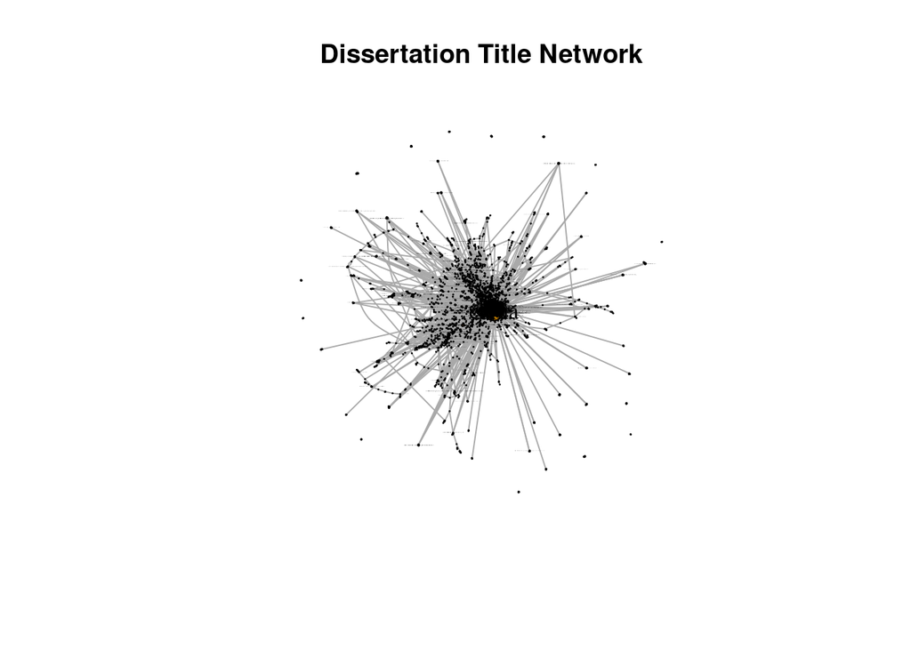

```r
# Plot the networks

# Index node size on degree centrality

deg_cent <- degree(title_net, mode = "all", normalized = TRUE)
V(title_net)$size <- deg_cent * 100

# Index node color on their type

V(title_net)$color <- ifelse(V(title_net)$Type == "Title", "red", "orange")

plot(title_net,
     vertex.size = V(title_net)$size,
     vertex.color = V(title_net)$color,
     vertex.label.color = "black",
     vertex.label.cex = V(title_net)$size/10,
     main = "Dissertation Title Network")
```

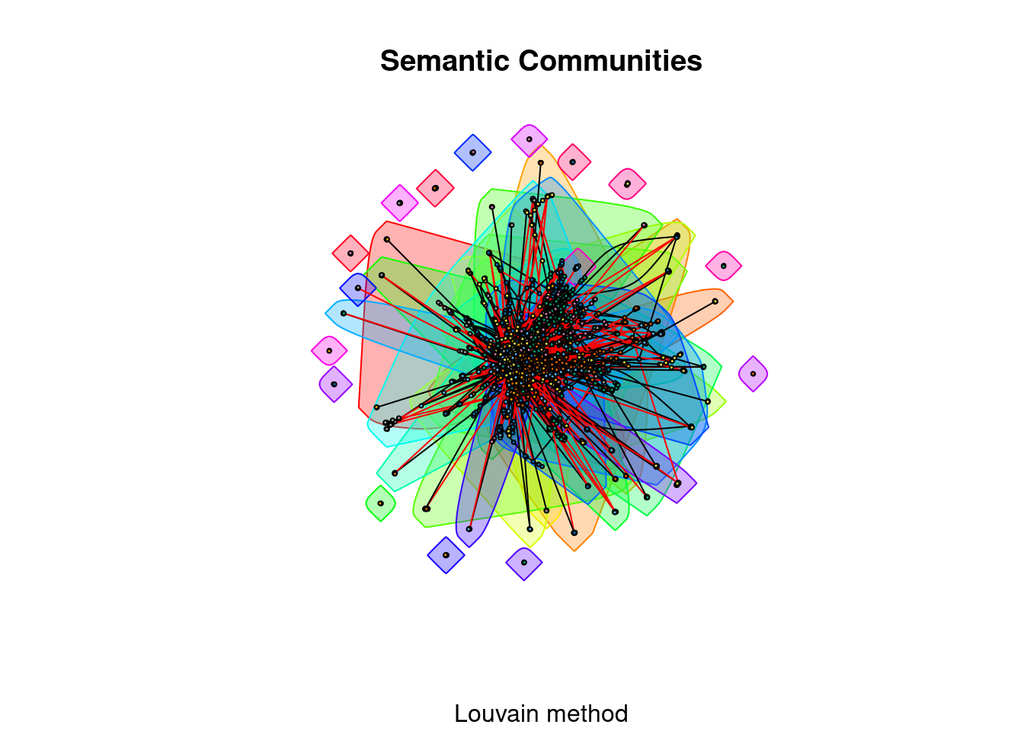

```r
# Plot the communities

V(title_net)$group <- title_net_cluster$membership
V(title_net)$color <- title_net_cluster$membership

plot(title_net_cluster, title_net,
     vertex.label=NA,
     vertex.label.color = "black",
     vertex.label.cex = 0.5,
     vertex.size=1.8,
     main="Semantic Communities",
     sub = "Louvain method")
```

## Biterm Topic Modeling

```r
library(BTM)

x <- shs_unigram %>% filter(!word == "study") %>%
  select(RID, word)


set.seed(2025)
model10  <- BTM(x, k = 10, beta = 0.01, iter = 1000, trace = 100)
```

```
## 2025-05-19 16:10:40 Start Gibbs sampling iteration 1/1000
## 2025-05-19 16:10:40 Start Gibbs sampling iteration 101/1000
## 2025-05-19 16:10:41 Start Gibbs sampling iteration 201/1000
## 2025-05-19 16:10:41 Start Gibbs sampling iteration 301/1000
## 2025-05-19 16:10:42 Start Gibbs sampling iteration 401/1000
## 2025-05-19 16:10:42 Start Gibbs sampling iteration 501/1000
## 2025-05-19 16:10:43 Start Gibbs sampling iteration 601/1000
## 2025-05-19 16:10:43 Start Gibbs sampling iteration 701/1000
## 2025-05-19 16:10:44 Start Gibbs sampling iteration 801/1000
## 2025-05-19 16:10:44 Start Gibbs sampling iteration 901/1000
```

```r
model15  <- BTM(x, k = 15, beta = 0.01, iter = 1000, trace = 100)
```

```
## 2025-05-19 16:10:45 Start Gibbs sampling iteration 1/1000
## 2025-05-19 16:10:45 Start Gibbs sampling iteration 101/1000
## 2025-05-19 16:10:46 Start Gibbs sampling iteration 201/1000
## 2025-05-19 16:10:47 Start Gibbs sampling iteration 301/1000
## 2025-05-19 16:10:47 Start Gibbs sampling iteration 401/1000
## 2025-05-19 16:10:48 Start Gibbs sampling iteration 501/1000
## 2025-05-19 16:10:49 Start Gibbs sampling iteration 601/1000
## 2025-05-19 16:10:49 Start Gibbs sampling iteration 701/1000
## 2025-05-19 16:10:50 Start Gibbs sampling iteration 801/1000
## 2025-05-19 16:10:51 Start Gibbs sampling iteration 901/1000
```

```r
model20  <- BTM(x, k = 20, beta = 0.01, iter = 1000, trace = 100)
```

```
## 2025-05-19 16:10:51 Start Gibbs sampling iteration 1/1000
## 2025-05-19 16:10:52 Start Gibbs sampling iteration 101/1000
## 2025-05-19 16:10:53 Start Gibbs sampling iteration 201/1000
## 2025-05-19 16:10:54 Start Gibbs sampling iteration 301/1000
## 2025-05-19 16:10:54 Start Gibbs sampling iteration 401/1000
## 2025-05-19 16:10:55 Start Gibbs sampling iteration 501/1000
## 2025-05-19 16:10:56 Start Gibbs sampling iteration 601/1000
## 2025-05-19 16:10:57 Start Gibbs sampling iteration 701/1000
## 2025-05-19 16:10:57 Start Gibbs sampling iteration 801/1000
## 2025-05-19 16:10:58 Start Gibbs sampling iteration 901/1000
```

```r
model25  <- BTM(x, k = 25, beta = 0.01, iter = 1000, trace = 100)
```

```
## 2025-05-19 16:10:59 Start Gibbs sampling iteration 1/1000
## 2025-05-19 16:11:00 Start Gibbs sampling iteration 101/1000
## 2025-05-19 16:11:01 Start Gibbs sampling iteration 201/1000
## 2025-05-19 16:11:02 Start Gibbs sampling iteration 301/1000
## 2025-05-19 16:11:03 Start Gibbs sampling iteration 401/1000
## 2025-05-19 16:11:04 Start Gibbs sampling iteration 501/1000
## 2025-05-19 16:11:05 Start Gibbs sampling iteration 601/1000
## 2025-05-19 16:11:06 Start Gibbs sampling iteration 701/1000
## 2025-05-19 16:11:06 Start Gibbs sampling iteration 801/1000
## 2025-05-19 16:11:07 Start Gibbs sampling iteration 901/1000
```

```r
# Most frequent terms and scores for each model

# model10$theta
# terms(model10, top_n = 10)
# topicterms10
# scores <- predict(model10, newdata = x)
# head(scores, 10)
# hist(scores)


# model20$theta
# terms(model20)
# model20 <- terms(model20, top_n = 10)
# topicterms10
# scores <- predict(model10, newdata = x)
# head(scores, 10)
# hist(scores)
```

```r
# Most frequent terms for each model

library(BTM)

## 10-topic model
terms(model10, top_n = 10)
```

```
## [[1]]
##         token probability
## 1       china  0.02625494
## 2   political  0.02450475
## 3    economic  0.02341089
## 4     chinese  0.01991052
## 5   influence  0.01597261
## 6         sen  0.01509752
## 7         sun  0.01509752
## 8         yat  0.01509752
## 9      social  0.01487875
## 10 philosophy  0.01465997
##
## [[2]]
##          token probability
```

[output cut: 114 more lines]

```r
## 15-topic model
terms(model15, top_n = 10)
```

```
## [[1]]
##          token probability
## 1      chinese  0.04227906
## 2          law  0.04086991
## 3          god  0.01926302
## 4         idea  0.01832359
## 5     doctrine  0.01691444
## 6           li  0.01597501
## 7    evolution  0.01456587
## 8     marriage  0.01456587
## 9        court  0.01268701
## 10 obligations  0.01268701
##
## [[2]]
##          token probability
```

[output cut: 179 more lines]

```r
## 20-topic model
terms(model20, top_n = 10)
```

```
## [[1]]
##            token probability
## 1          basis  0.02323834
## 2        chinese  0.02076670
## 3           east  0.02027237
## 4    supervision  0.02027237
## 5       selected  0.01928372
## 6       american  0.01878939
## 7  international  0.01780074
## 8         county  0.01483477
## 9       economic  0.01384612
## 10           war  0.01384612
##
## [[2]]
##          token probability
```

[output cut: 244 more lines]

```r
## 25-topic model
terms(model25, top_n = 10)
```

```
## [[1]]
##       token probability
## 1   chinese  0.07815845
## 2     china  0.03059063
## 3      life  0.03059063
## 4        lu  0.02153010
## 5    native  0.01926496
## 6   tibetan  0.01926496
## 7   century  0.01813240
## 8  movement  0.01699983
## 9      pali  0.01699983
## 10 sanskrit  0.01699983
##
## [[2]]
##         token probability
```

[output cut: 309 more lines]

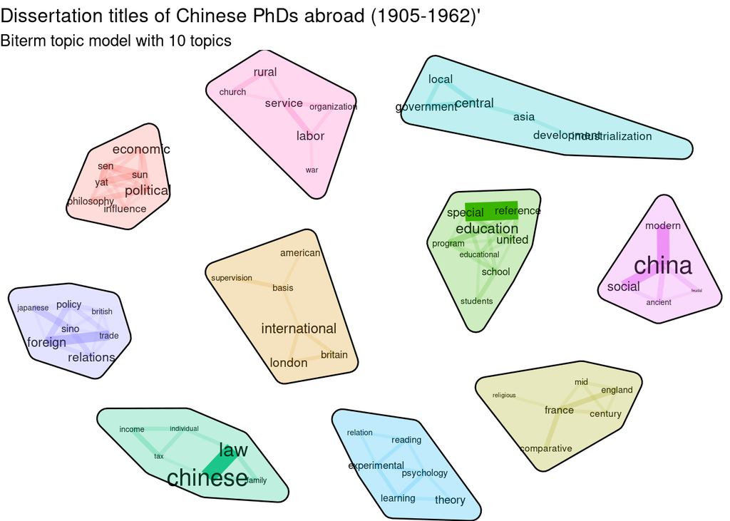

```r
# Plot the topics

library(BTM)
library(textplot)
library(ggraph)
library(concaveman)

plot(model10, top_n = 10,
     title = "Dissertation titles of Chinese PhDs abroad (1905-1962)'",
     subtitle = "Biterm topic model with 10 topics")
```

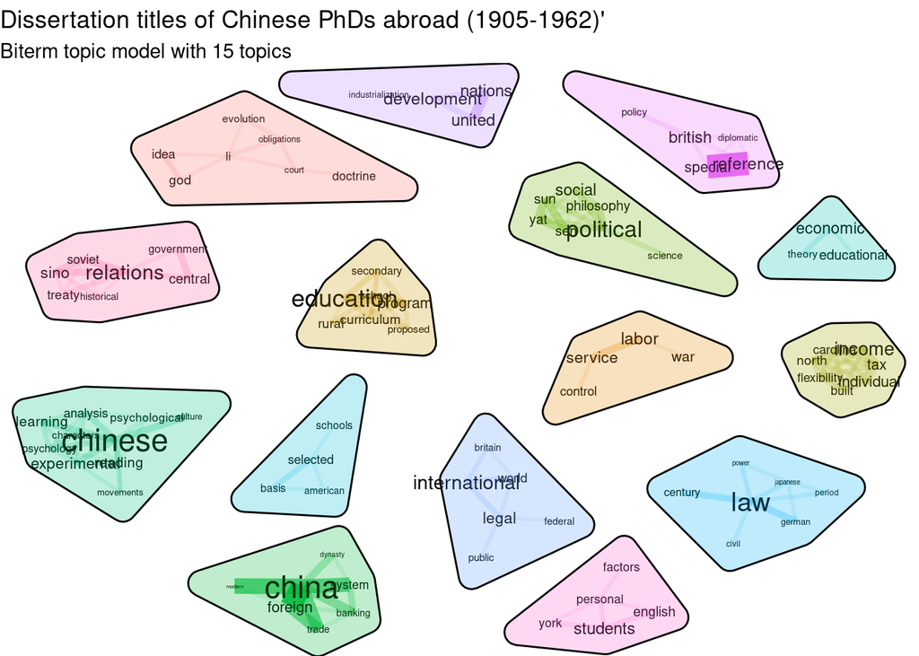

```r
plot(model15, top_n = 10,
     title = "Dissertation titles of Chinese PhDs abroad (1905-1962)'",
     subtitle = "Biterm topic model with 15 topics")
```

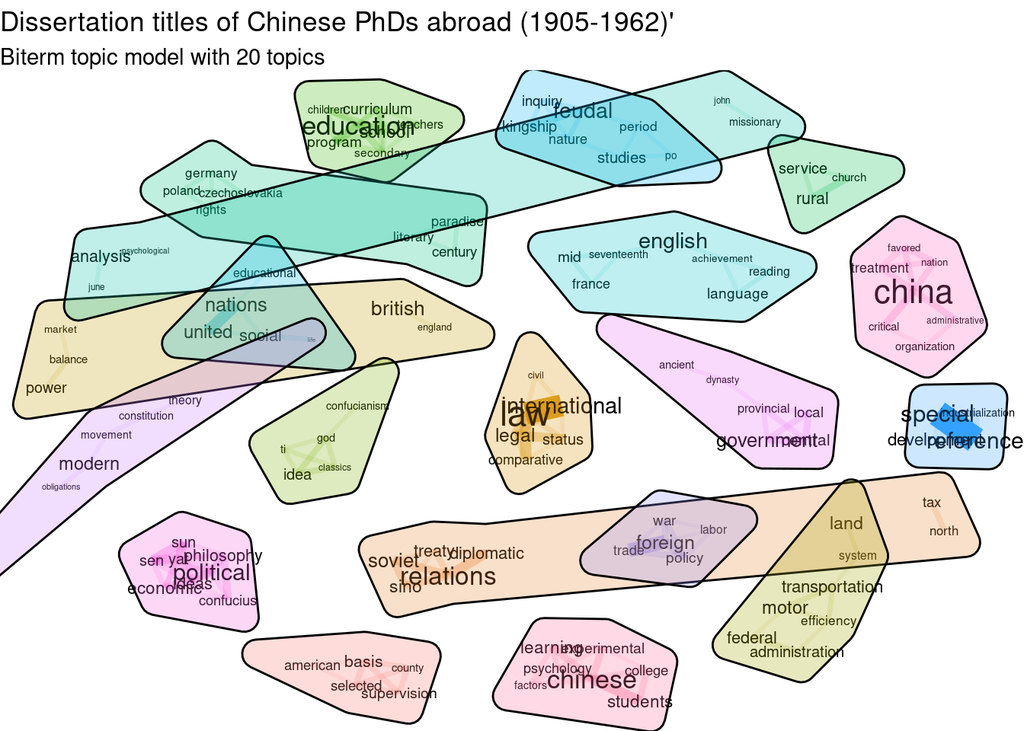

```r
plot(model20, top_n = 10,
     title = "Dissertation titles of Chinese PhDs abroad (1905-1962)'",
     subtitle = "Biterm topic model with 20 topics")
```

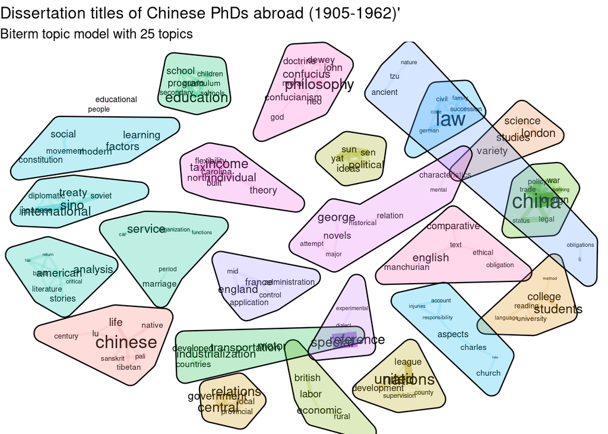

```r
plot(model25, top_n = 10,
     title = "Dissertation titles of Chinese PhDs abroad (1905-1962)'",
     subtitle = "Biterm topic model with 25 topics")
```

### By Region

```r
# Build Models

usa <- shs_unigram %>% filter(!word == "study") %>%
  filter(lgth >3 ) %>% filter(Region == "USA") %>%
  select(RID, word)
uk <- shs_unigram %>% filter(!word == "study") %>%
  filter(lgth >3 ) %>%  filter(Region == "UK") %>%
  select(RID, word)
eu <- shs_unigram %>% filter(!word == "study") %>%
filter(lgth >3 ) %>% filter(Region == "Europe") %>%
  select(RID, word)

set.seed(321)
model10us  <- BTM(usa, k = 10, beta = 0.01, iter = 1000, trace = 100)
```

```
## 2025-05-19 16:11:12 Start Gibbs sampling iteration 1/1000
## 2025-05-19 16:11:12 Start Gibbs sampling iteration 101/1000
## 2025-05-19 16:11:12 Start Gibbs sampling iteration 201/1000
## 2025-05-19 16:11:12 Start Gibbs sampling iteration 301/1000
## 2025-05-19 16:11:13 Start Gibbs sampling iteration 401/1000
## 2025-05-19 16:11:13 Start Gibbs sampling iteration 501/1000
## 2025-05-19 16:11:13 Start Gibbs sampling iteration 601/1000
## 2025-05-19 16:11:13 Start Gibbs sampling iteration 701/1000
## 2025-05-19 16:11:14 Start Gibbs sampling iteration 801/1000
## 2025-05-19 16:11:14 Start Gibbs sampling iteration 901/1000
```

```r
model15us  <- BTM(usa, k = 15, beta = 0.01, iter = 1000, trace = 100)
```

```
## 2025-05-19 16:11:14 Start Gibbs sampling iteration 1/1000
## 2025-05-19 16:11:15 Start Gibbs sampling iteration 101/1000
## 2025-05-19 16:11:15 Start Gibbs sampling iteration 201/1000
## 2025-05-19 16:11:15 Start Gibbs sampling iteration 301/1000
## 2025-05-19 16:11:16 Start Gibbs sampling iteration 401/1000
## 2025-05-19 16:11:16 Start Gibbs sampling iteration 501/1000
## 2025-05-19 16:11:16 Start Gibbs sampling iteration 601/1000
## 2025-05-19 16:11:17 Start Gibbs sampling iteration 701/1000
## 2025-05-19 16:11:17 Start Gibbs sampling iteration 801/1000
## 2025-05-19 16:11:17 Start Gibbs sampling iteration 901/1000
```

```r
model20us  <- BTM(usa, k = 20, beta = 0.01, iter = 1000, trace = 100)
```

```
## 2025-05-19 16:11:18 Start Gibbs sampling iteration 1/1000
## 2025-05-19 16:11:18 Start Gibbs sampling iteration 101/1000
## 2025-05-19 16:11:19 Start Gibbs sampling iteration 201/1000
## 2025-05-19 16:11:19 Start Gibbs sampling iteration 301/1000
## 2025-05-19 16:11:19 Start Gibbs sampling iteration 401/1000
## 2025-05-19 16:11:20 Start Gibbs sampling iteration 501/1000
## 2025-05-19 16:11:20 Start Gibbs sampling iteration 601/1000
## 2025-05-19 16:11:21 Start Gibbs sampling iteration 701/1000
## 2025-05-19 16:11:21 Start Gibbs sampling iteration 801/1000
## 2025-05-19 16:11:22 Start Gibbs sampling iteration 901/1000
```

```r
model25us  <- BTM(usa, k = 25, beta = 0.01, iter = 1000, trace = 100)
```

```
## 2025-05-19 16:11:22 Start Gibbs sampling iteration 1/1000
## 2025-05-19 16:11:23 Start Gibbs sampling iteration 101/1000
## 2025-05-19 16:11:23 Start Gibbs sampling iteration 201/1000
## 2025-05-19 16:11:24 Start Gibbs sampling iteration 301/1000
## 2025-05-19 16:11:24 Start Gibbs sampling iteration 401/1000
## 2025-05-19 16:11:25 Start Gibbs sampling iteration 501/1000
## 2025-05-19 16:11:25 Start Gibbs sampling iteration 601/1000
## 2025-05-19 16:11:26 Start Gibbs sampling iteration 701/1000
## 2025-05-19 16:11:26 Start Gibbs sampling iteration 801/1000
## 2025-05-19 16:11:27 Start Gibbs sampling iteration 901/1000
```

```r
model5uk  <- BTM(uk, k = 5, beta = 0.01, iter = 1000, trace = 100)
```

```
## 2025-05-19 16:11:27 Start Gibbs sampling iteration 1/1000
## 2025-05-19 16:11:27 Start Gibbs sampling iteration 101/1000
## 2025-05-19 16:11:27 Start Gibbs sampling iteration 201/1000
## 2025-05-19 16:11:27 Start Gibbs sampling iteration 301/1000
## 2025-05-19 16:11:27 Start Gibbs sampling iteration 401/1000
## 2025-05-19 16:11:27 Start Gibbs sampling iteration 501/1000
## 2025-05-19 16:11:27 Start Gibbs sampling iteration 601/1000
## 2025-05-19 16:11:27 Start Gibbs sampling iteration 701/1000
## 2025-05-19 16:11:27 Start Gibbs sampling iteration 801/1000
## 2025-05-19 16:11:27 Start Gibbs sampling iteration 901/1000
```

```r
model10uk  <- BTM(uk, k = 10, beta = 0.01, iter = 1000, trace = 100)
```

```
## 2025-05-19 16:11:27 Start Gibbs sampling iteration 1/1000
## 2025-05-19 16:11:27 Start Gibbs sampling iteration 101/1000
## 2025-05-19 16:11:27 Start Gibbs sampling iteration 201/1000
## 2025-05-19 16:11:27 Start Gibbs sampling iteration 301/1000
## 2025-05-19 16:11:27 Start Gibbs sampling iteration 401/1000
## 2025-05-19 16:11:27 Start Gibbs sampling iteration 501/1000
## 2025-05-19 16:11:27 Start Gibbs sampling iteration 601/1000
## 2025-05-19 16:11:27 Start Gibbs sampling iteration 701/1000
## 2025-05-19 16:11:28 Start Gibbs sampling iteration 801/1000
## 2025-05-19 16:11:28 Start Gibbs sampling iteration 901/1000
```

```r
model15uk  <- BTM(uk, k = 15, beta = 0.01, iter = 1000, trace = 100)
```

```
## 2025-05-19 16:11:28 Start Gibbs sampling iteration 1/1000
## 2025-05-19 16:11:28 Start Gibbs sampling iteration 101/1000
## 2025-05-19 16:11:28 Start Gibbs sampling iteration 201/1000
## 2025-05-19 16:11:28 Start Gibbs sampling iteration 301/1000
## 2025-05-19 16:11:28 Start Gibbs sampling iteration 401/1000
## 2025-05-19 16:11:28 Start Gibbs sampling iteration 501/1000
## 2025-05-19 16:11:28 Start Gibbs sampling iteration 601/1000
## 2025-05-19 16:11:28 Start Gibbs sampling iteration 701/1000
## 2025-05-19 16:11:28 Start Gibbs sampling iteration 801/1000
## 2025-05-19 16:11:28 Start Gibbs sampling iteration 901/1000
```

```r
model10eu  <- BTM(eu, k = 10, beta = 0.01, iter = 1000, trace = 100)
```

```
## 2025-05-19 16:11:28 Start Gibbs sampling iteration 1/1000
## 2025-05-19 16:11:28 Start Gibbs sampling iteration 101/1000
## 2025-05-19 16:11:28 Start Gibbs sampling iteration 201/1000
## 2025-05-19 16:11:28 Start Gibbs sampling iteration 301/1000
## 2025-05-19 16:11:29 Start Gibbs sampling iteration 401/1000
## 2025-05-19 16:11:29 Start Gibbs sampling iteration 501/1000
## 2025-05-19 16:11:29 Start Gibbs sampling iteration 601/1000
## 2025-05-19 16:11:29 Start Gibbs sampling iteration 701/1000
## 2025-05-19 16:11:29 Start Gibbs sampling iteration 801/1000
## 2025-05-19 16:11:29 Start Gibbs sampling iteration 901/1000
```

```r
model15eu  <- BTM(eu, k = 15, beta = 0.01, iter = 1000, trace = 100)
```

```
## 2025-05-19 16:11:29 Start Gibbs sampling iteration 1/1000
## 2025-05-19 16:11:30 Start Gibbs sampling iteration 101/1000
## 2025-05-19 16:11:30 Start Gibbs sampling iteration 201/1000
## 2025-05-19 16:11:30 Start Gibbs sampling iteration 301/1000
## 2025-05-19 16:11:30 Start Gibbs sampling iteration 401/1000
## 2025-05-19 16:11:30 Start Gibbs sampling iteration 501/1000
## 2025-05-19 16:11:31 Start Gibbs sampling iteration 601/1000
## 2025-05-19 16:11:31 Start Gibbs sampling iteration 701/1000
## 2025-05-19 16:11:31 Start Gibbs sampling iteration 801/1000
## 2025-05-19 16:11:31 Start Gibbs sampling iteration 901/1000
```

```r
model20eu  <- BTM(eu, k = 20, beta = 0.01, iter = 1000, trace = 100)
```

```
## 2025-05-19 16:11:31 Start Gibbs sampling iteration 1/1000
## 2025-05-19 16:11:32 Start Gibbs sampling iteration 101/1000
## 2025-05-19 16:11:32 Start Gibbs sampling iteration 201/1000
## 2025-05-19 16:11:32 Start Gibbs sampling iteration 301/1000
## 2025-05-19 16:11:32 Start Gibbs sampling iteration 401/1000
## 2025-05-19 16:11:33 Start Gibbs sampling iteration 501/1000
## 2025-05-19 16:11:33 Start Gibbs sampling iteration 601/1000
## 2025-05-19 16:11:33 Start Gibbs sampling iteration 701/1000
## 2025-05-19 16:11:33 Start Gibbs sampling iteration 801/1000
## 2025-05-19 16:11:33 Start Gibbs sampling iteration 901/1000
```

```r
# Most frequent terms for each model

## U.S. theses models with 10, 20, and 25 topics
terms(model10us)
```

```
## [[1]]
##      token probability
## 1  chinese  0.03615592
## 2 american  0.03389665
## 3   method  0.02335337
## 4  stories  0.02109409
## 5    basis  0.01808173
##
## [[2]]
##           token probability
## 1         china  0.05946573
## 2       chinese  0.02801636
## 3       foreign  0.02405216
## 4 international  0.01929511
## 5      american  0.01850227
##
## [[3]]
##        token probability
## 1    chinese  0.05854293
## 2   students  0.04042357
## 3    college  0.02021353
## 4    reading  0.01916818
## 5 university  0.01603214
##
## [[4]]
##       token probability
## 1   chinese  0.03929508
## 2 reference  0.03764072
## 3   special  0.03267766
## 4    united  0.02812818
## 5     china  0.02564665
##
## [[5]]
##         token probability
## 1       china  0.03343227
## 2      feudal  0.02407311
## 3 development  0.01805650
## 4      visual  0.01671948
## 5    kingship  0.01605097
##
```

[output cut: 24 more lines]

```
## [[9]]
##        token probability
## 1    chinese  0.05317800
## 2    factors  0.02524894
## 3   learning  0.02148926
## 4 conference  0.01880378
## 5   analysis  0.01826668
##
## [[10]]
##        token probability
## 1      china  0.03966740
## 2    chinese  0.02786303
## 3 philosophy  0.02408563
## 4     income  0.02314128
## 5  influence  0.01841954
```

```r
terms(model20us)
```

```
## [[1]]
##        token probability
## 1      china  0.04960921
## 2    chinese  0.04357648
## 3  relations  0.02882978
## 4    foreign  0.02815948
## 5 diplomatic  0.02614857
##
## [[2]]
##        token probability
## 1   analysis  0.03482582
## 2    chinese  0.02638575
## 3       farm  0.02216572
## 4 attainment  0.02111071
## 5       goal  0.02111071
##
## [[3]]
##         token probability
## 1     chinese  0.07694527
## 2    american  0.03527237
## 3     stories  0.03527237
## 4 comparative  0.02565555
## 5     foreign  0.02031287
##
## [[4]]
##      token probability
## 1 selected  0.02619861
## 2   united  0.02560332
## 3    china  0.02500804
## 4   county  0.02500804
## 5    hsien  0.02500804
##
## [[5]]
##            token probability
## 1         united  0.04412680
## 2        special  0.04242983
## 3      reference  0.03960155
## 4 administration  0.03111672
## 5        control  0.02828844
##
```

[output cut: 104 more lines]

```
## [[19]]
##        token probability
## 1 philosophy  0.04990286
## 2  education  0.03610141
## 3      china  0.03132398
## 4  political  0.02760821
## 5  confucius  0.02548491
##
## [[20]]
##      token probability
## 1  chinese  0.05086197
## 2 american  0.03560592
## 3  english  0.02967301
## 4 children  0.02628278
## 5 language  0.02458766
```

```r
terms(model25us)
```

```
## [[1]]
##       token probability
## 1 reference  0.05539808
## 2   special  0.04791253
## 3     china  0.04042698
## 4    united  0.03294142
## 5  economic  0.02345972
##
## [[2]]
##     token probability
## 1   china  0.07144218
## 2   rural  0.03810567
## 3 chinese  0.02994163
## 4   hsien  0.02790062
## 5  united  0.02790062
##
## [[3]]
##            token probability
## 1          china  0.04183630
## 2        england  0.03347090
## 3 administration  0.02789396
## 4        systems  0.02510550
## 5   organization  0.02324652
##
## [[4]]
##       token probability
## 1   chinese  0.07711511
## 2 education  0.03588933
## 3  learning  0.03512589
## 4   reading  0.03283557
## 5     adult  0.03130869
##
## [[5]]
##       token probability
## 1   chinese  0.06755160
## 2     china  0.03800701
## 3 formation  0.03378635
## 4   capital  0.03167602
## 5     prior  0.02956569
##
```

[output cut: 144 more lines]

```
## [[24]]
##       token probability
## 1     china  0.05466366
## 2 education  0.03426982
## 3    united  0.02937530
## 4      plan  0.02529653
## 5   control  0.02284927
##
## [[25]]
##        token probability
## 1  education  0.10542486
## 2      china  0.06980996
## 3    chinese  0.04036831
## 4    program  0.03324532
## 5 curriculum  0.02849667
```

```r
## UK theses models with 5 and 10 topics
terms(model5uk)
```

```
## [[1]]
##       token probability
## 1    treaty  0.04974356
## 2 reference  0.04041859
## 3   special  0.04041859
## 4     china  0.03731026
## 5   british  0.03109361
##
## [[2]]
##       token probability
## 1   special  0.05121918
## 2      asia  0.04313620
## 3 borrowing  0.04313620
## 4 reference  0.04313620
## 5   capital  0.03774754
##
## [[3]]
##        token probability
## 1     george  0.06235715
## 2      china  0.04388780
## 3 historical  0.03465312
## 4    charles  0.02541845
## 5    dickens  0.02541845
##
## [[4]]
##       token probability
## 1 political  0.06648579
## 2    london  0.04613715
## 3   science  0.04206742
## 4   english  0.03935427
## 5   chinese  0.03121481
##
## [[5]]
##           token probability
## 1 international  0.06078770
## 2        soviet  0.04648752
## 3        london  0.04291247
## 4     relations  0.03814574
## 5          sino  0.03814574
```

```r
terms(model10uk)
```

```
## [[1]]
##        token probability
## 1      trade  0.06866824
## 2    british  0.04722282
## 3 government  0.04722282
## 4      local  0.04722282
## 5      china  0.04293373
##
## [[2]]
##        token probability
## 1    chinese  0.07424330
## 2      china  0.05800765
## 3  relations  0.04873014
## 4 diplomatic  0.03713325
## 5     treaty  0.03713325
##
## [[3]]
##           token probability
## 1 international  0.06768164
## 2        soviet  0.06599002
## 3        london  0.06260678
## 4     relations  0.05584031
## 5          sino  0.05414869
##
## [[4]]
##       token probability
## 1 reference  0.10995782
## 2   special  0.10740125
## 3      asia  0.04093059
## 4  economic  0.03837403
## 5   capital  0.03581746
##
## [[5]]
##        token probability
## 1      power  0.04035719
## 2      china  0.03459600
## 3 principles  0.03171540
## 4  structure  0.03171540
## 5 biological  0.02883480
##
```

[output cut: 24 more lines]

```
## [[9]]
##        token probability
## 1     george  0.10135851
## 2 historical  0.06912273
## 3    charles  0.05070228
## 4    dickens  0.05070228
## 5      eliot  0.05070228
##
## [[10]]
##         token probability
## 1       china  0.08936645
## 2     dialect  0.07820262
## 3       tones  0.07820262
## 4 descriptive  0.05587497
## 5     chengtu  0.04471114
```

```r
## Europe theses models with 10 and 20 topics
terms(model10eu)
```

```
## [[1]]
##     token probability
## 1  france  0.02956595
## 2   power  0.02442628
## 3  sacred  0.02314137
## 4   china  0.01671678
## 5 blessed  0.01543186
##
## [[2]]
##           token probability
## 1         china  0.06866391
## 2         labor  0.04291763
## 3       service  0.03576588
## 4  organization  0.03290518
## 5 international  0.03075966
##
## [[3]]
##     token probability
## 1   china  0.09764387
## 2 chinese  0.05069201
## 3  system  0.03895404
## 4   trade  0.03842050
## 5 foreign  0.03735341
##
## [[4]]
##      token probability
## 1  chinese  0.06692331
## 2    china  0.02205060
## 3 relation  0.01732716
## 4   orphan  0.01417820
## 5 phonetic  0.01417820
##
## [[5]]
##          token probability
## 1        china  0.08832970
## 2      chinese  0.06004295
## 3       modern  0.03060164
## 4   government  0.02482884
## 5 relationship  0.02078787
##
```

[output cut: 24 more lines]

```
## [[9]]
##        token probability
## 1      china  0.10834750
## 2    chinese  0.02891428
## 3 historical  0.02307360
## 4  relations  0.02102936
## 5    foreign  0.01986123
##
## [[10]]
##        token probability
## 1    chinese  0.05225227
## 2 obligation  0.03681761
## 3   critical  0.03206848
## 4      moral  0.02731936
## 5    history  0.02375751
```

```r
terms(model20eu)
```

```
## [[1]]
##          token probability
## 1        china  0.14846765
## 2       regime  0.04455184
## 3 organization  0.03795401
## 4    education  0.03630456
## 5       public  0.03630456
##
## [[2]]
##       token probability
## 1   nations  0.06205839
## 2     china  0.04310137
## 3    united  0.03793127
## 4 manchuria  0.03620791
## 5    league  0.03103781
##
## [[3]]
##         token probability
## 1       china  0.09289948
## 2      france  0.04866865
## 3 comparative  0.03392504
## 4       labor  0.02507888
## 5    teaching  0.02507888
##
## [[4]]
##        token probability
## 1 obligation  0.06306916
## 2      moral  0.04905898
## 3       role  0.03971886
## 4      basis  0.02570868
## 5    charles  0.02570868
##
## [[5]]
##       token probability
## 1     china  0.13346553
## 2   chinese  0.05203354
## 3 relations  0.03770754
## 4    powers  0.03242954
## 5 evolution  0.02790554
##
```

[output cut: 104 more lines]

```
## [[19]]
##            token probability
## 1        chinese  0.04191482
## 2          china  0.03443271
## 3         social  0.02994344
## 4       phonetic  0.02695059
## 5 czechoslovakia  0.02395774
##
## [[20]]
##       token probability
## 1   chinese  0.04796592
## 2   society  0.03505698
## 3 christian  0.03321285
## 4    german  0.03136872
## 5      pope  0.02768045
```

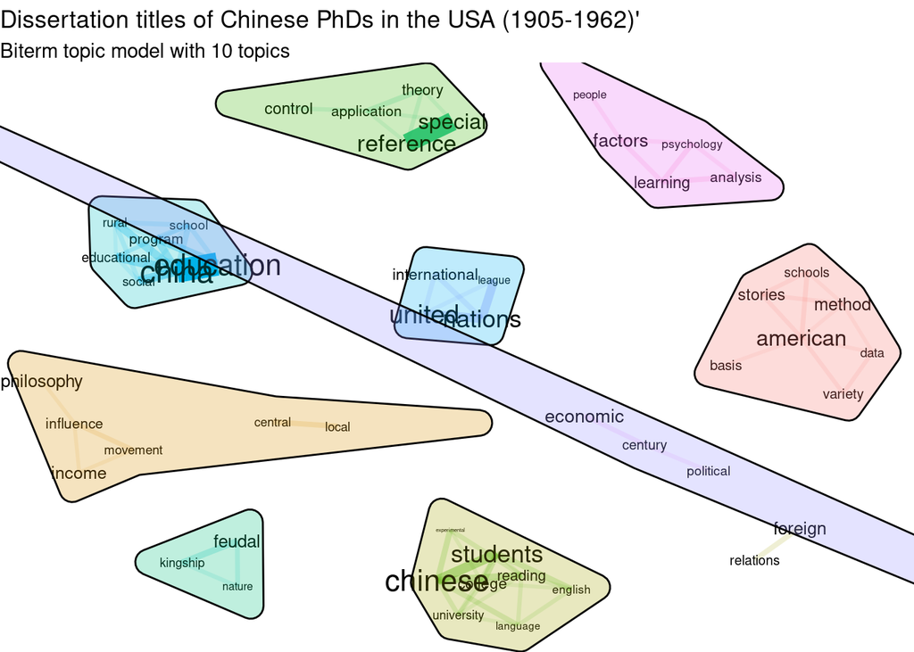

```r
# Plot the topics

plot(model10us, top_n = 8,
     title = "Dissertation titles of Chinese PhDs in the USA (1905-1962)'",
     subtitle = "Biterm topic model with 10 topics")
```

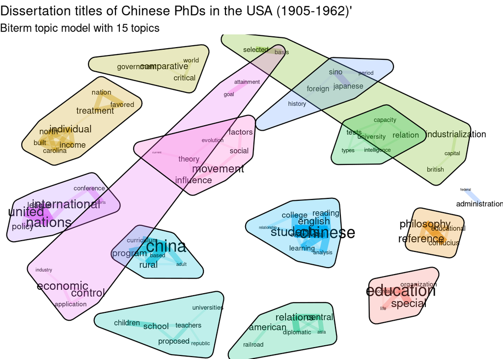

```r
plot(model15us, top_n = 10,
     title = "Dissertation titles of Chinese PhDs in the USA (1905-1962)'",
     subtitle = "Biterm topic model with 15 topics")
```

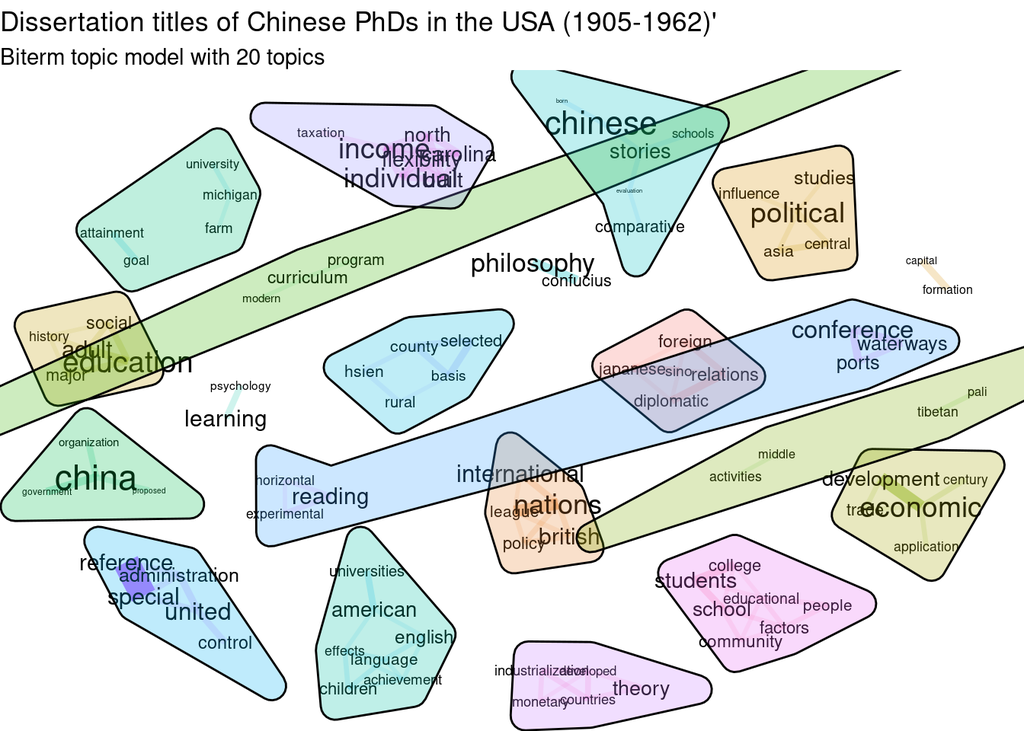

```r
plot(model20us, top_n = 8,
     title = "Dissertation titles of Chinese PhDs in the USA (1905-1962)'",
     subtitle = "Biterm topic model with 20 topics")
```

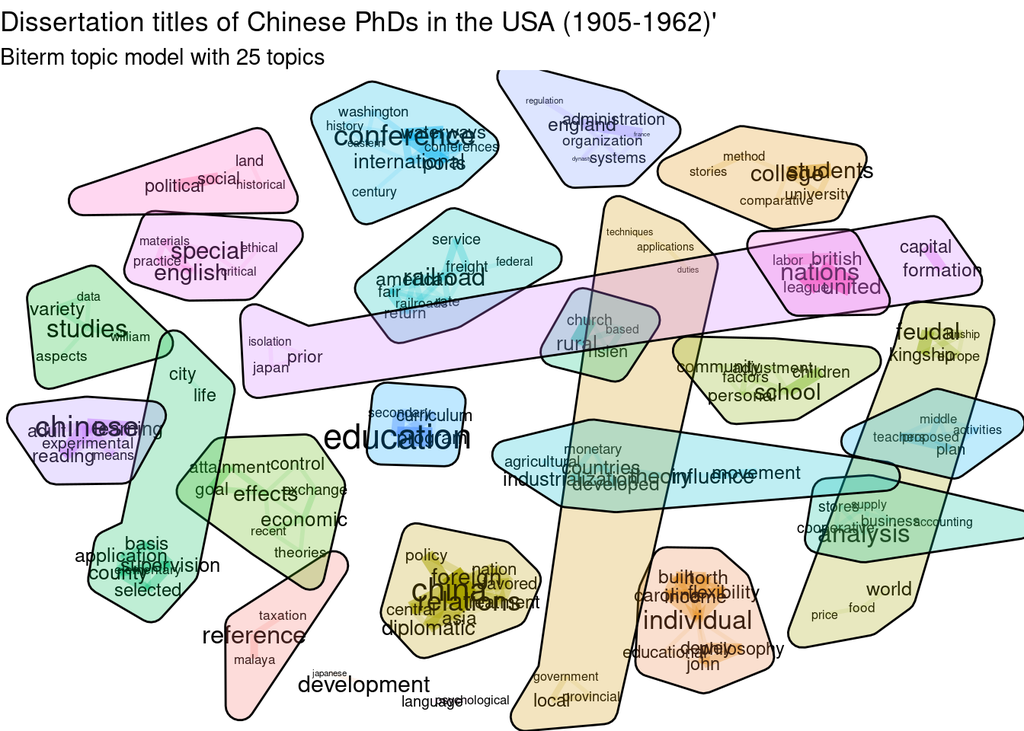

```r
plot(model25us, top_n = 10,
     title = "Dissertation titles of Chinese PhDs in the USA (1905-1962)'",
     subtitle = "Biterm topic model with 25 topics")
```

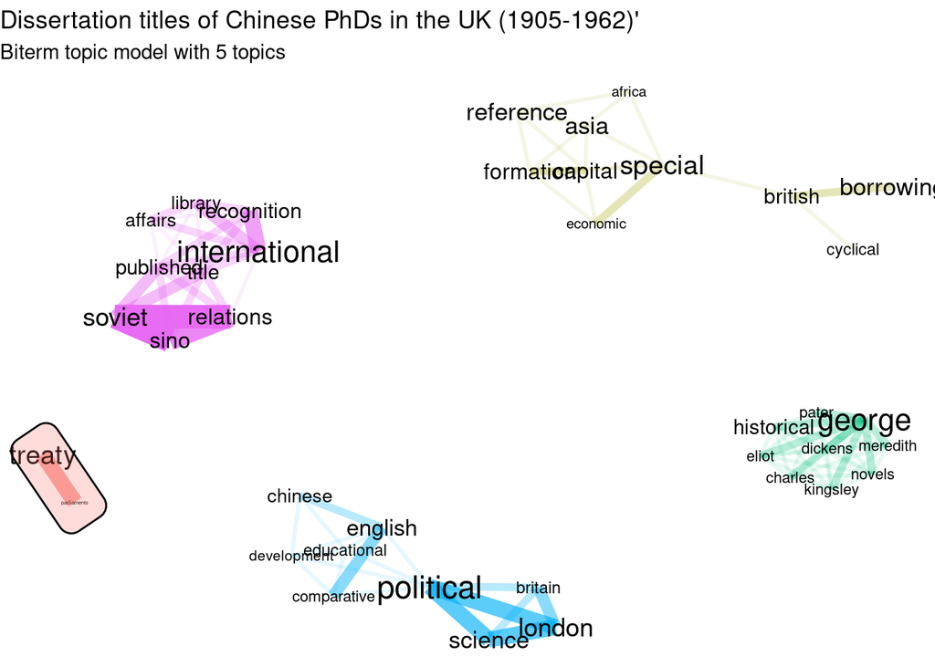

```r
plot(model5uk, top_n = 10,
     title = "Dissertation titles of Chinese PhDs in the UK (1905-1962)'",
     subtitle = "Biterm topic model with 5 topics")
```

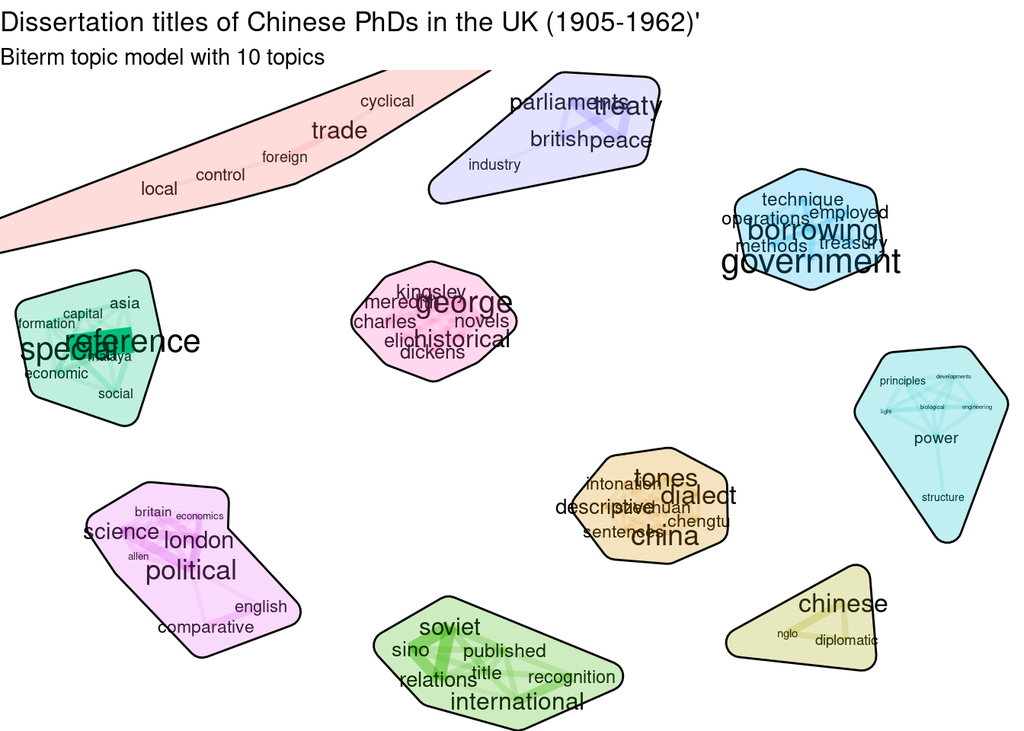

```r
plot(model10uk, top_n = 8,
     title = "Dissertation titles of Chinese PhDs in the UK (1905-1962)'",
     subtitle = "Biterm topic model with 10 topics")
```

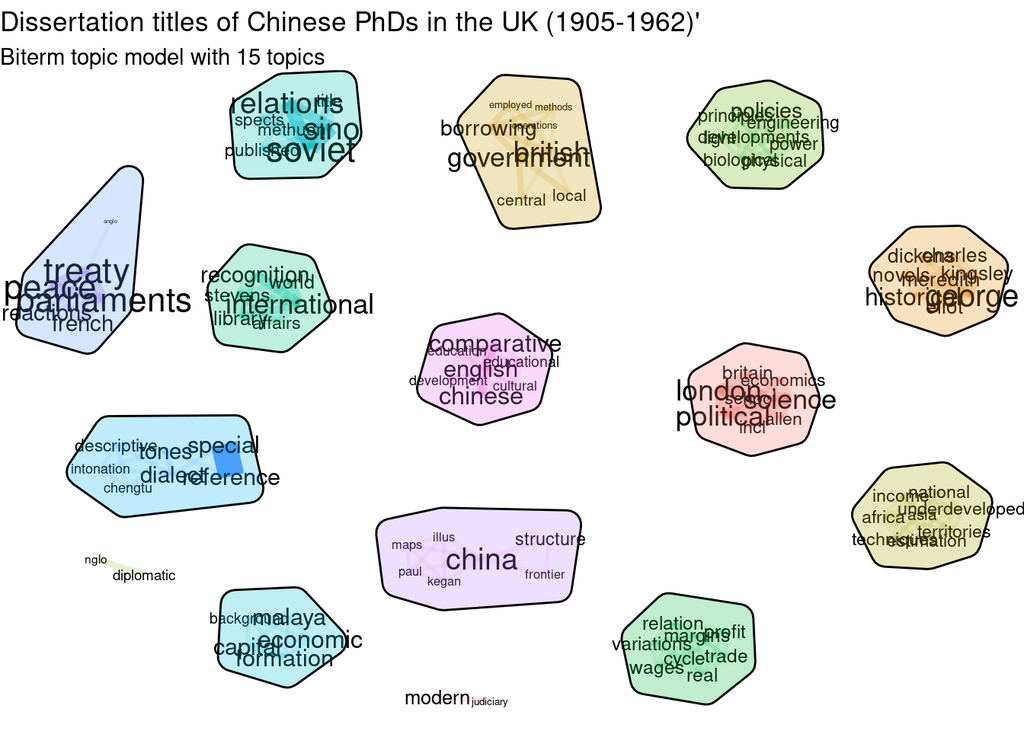

```r
plot(model15uk, top_n = 8,
     title = "Dissertation titles of Chinese PhDs in the UK (1905-1962)'",
     subtitle = "Biterm topic model with 15 topics")
```

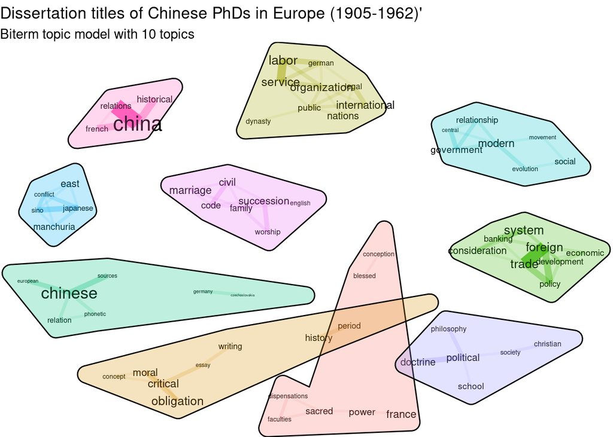

```r
plot(model10eu, top_n = 10,
     title = "Dissertation titles of Chinese PhDs in Europe (1905-1962)'",
     subtitle = "Biterm topic model with 10 topics")
```

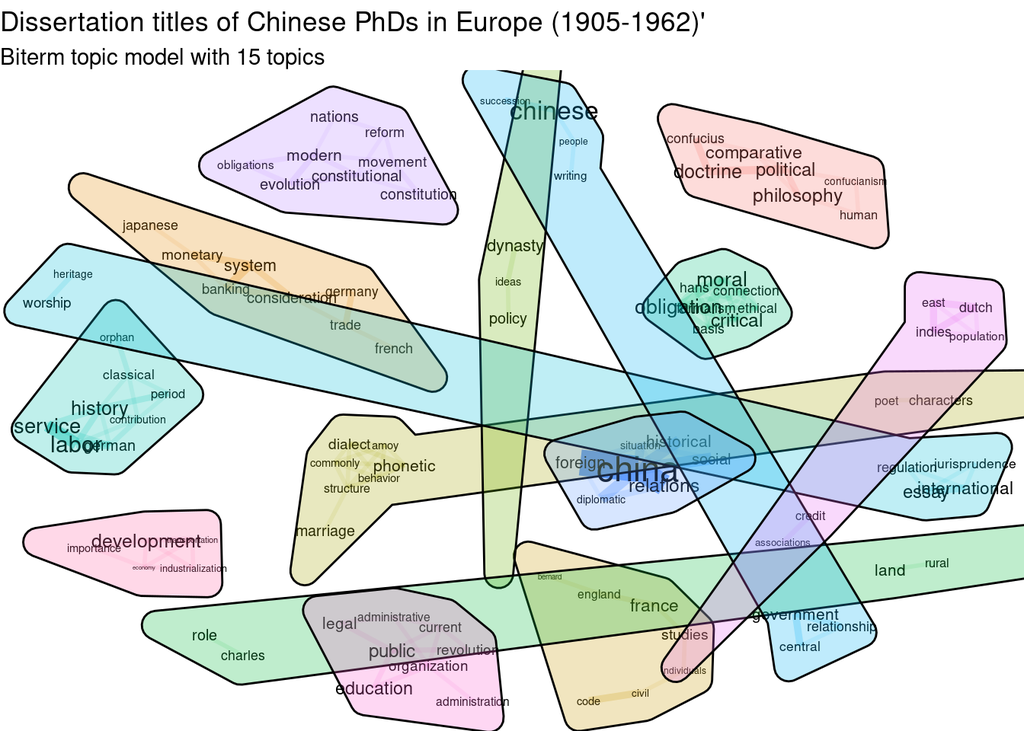

```r
plot(model15eu, top_n = 10,
     title = "Dissertation titles of Chinese PhDs in Europe (1905-1962)'",
     subtitle = "Biterm topic model with 15 topics")
```

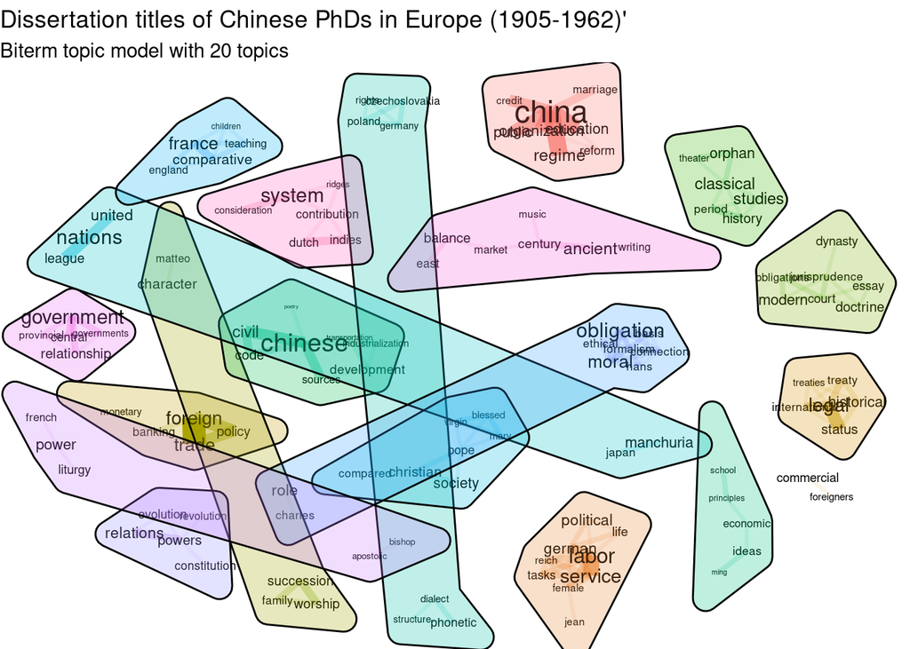

```r
plot(model20eu, top_n = 10,
     title = "Dissertation titles of Chinese PhDs in Europe (1905-1962)'",
     subtitle = "Biterm topic model with 20 topics")
```